# 11_18_meeting_report

### 00820:#X DRNK/LAST12MO

On how many occasions (if any) have you had alcoholic beverages to drink–more than just a few sips . . . during the last 12 months?

1=“0 Occasions” 2=“1-2 Occasions” 3=“3-5 Occasions” 4=“6-9 Occasions” 5=“10-19 Occasions” 6=“20-39 Occasions” 7=“40 or More”

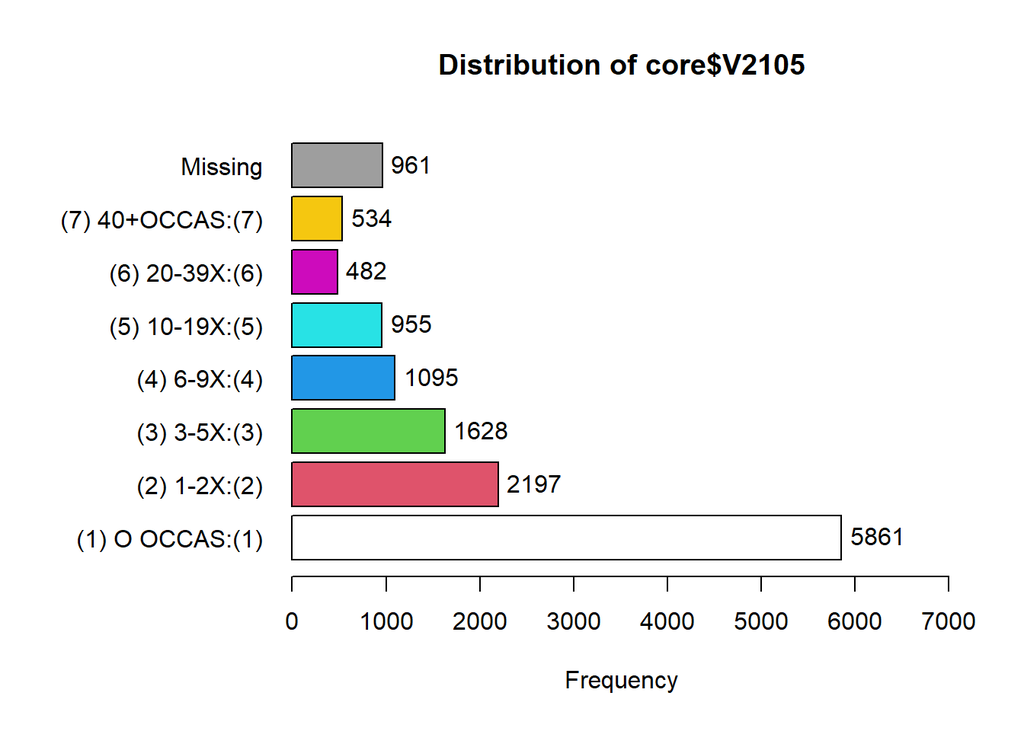

```
## core$V2105 :
##                  Frequency   %(NA+) cum.%(NA+)   %(NA-) cum.%(NA-)
## (1) O OCCAS:(1)       5861     42.7       42.7     46.0       46.0
## (2) 1-2X:(2)          2197     16.0       58.8     17.2       63.2
## (3) 3-5X:(3)          1628     11.9       70.6     12.8       76.0
## (4) 6-9X:(4)          1095      8.0       78.6      8.6       84.5
## (5) 10-19X:(5)         955      7.0       85.6      7.5       92.0
## (6) 20-39X:(6)         482      3.5       89.1      3.8       95.8
## (7) 40+OCCAS:(7)       534      3.9       93.0      4.2      100.0
## NA's                   961      7.0      100.0      0.0      100.0
##   Total              13713    100.0      100.0    100.0      100.0
```

```r
tab1(core$V2105, cum.percent = TRUE)
```

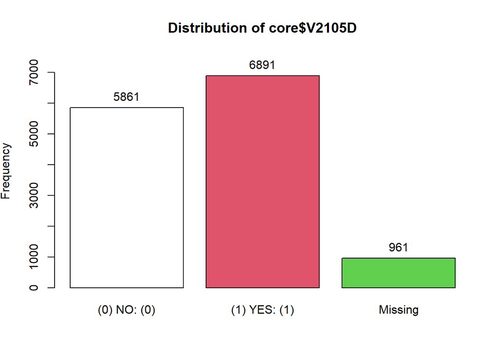

```
## core$V2105D :
##              Frequency   %(NA+) cum.%(NA+)   %(NA-) cum.%(NA-)
## (0) NO: (0)       5861     42.7       42.7       46         46
## (1) YES: (1)      6891     50.3       93.0       54        100
## NA's               961      7.0      100.0        0        100
##   Total          13713    100.0      100.0      100        100
```

```r
tab1(core$V2105D, cum.percent = TRUE)
```

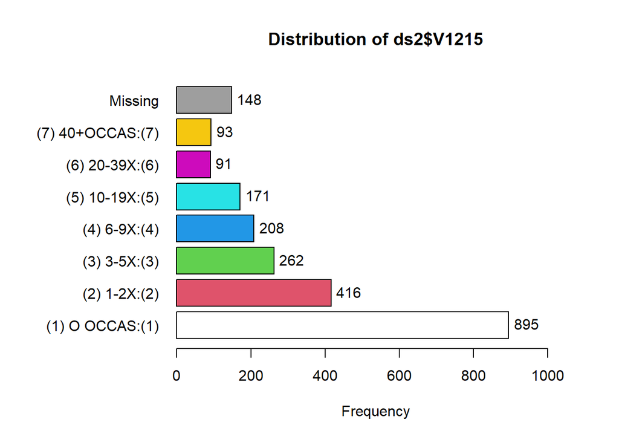

```
## ds2$V1215 :
##                  Frequency   %(NA+) cum.%(NA+)   %(NA-) cum.%(NA-)
## (1) O OCCAS:(1)        895     39.2       39.2     41.9       41.9
## (2) 1-2X:(2)           416     18.2       57.4     19.5       61.4
## (3) 3-5X:(3)           262     11.5       68.9     12.3       73.6
## (4) 6-9X:(4)           208      9.1       78.0      9.7       83.4
## (5) 10-19X:(5)         171      7.5       85.5      8.0       91.4
## (6) 20-39X:(6)          91      4.0       89.4      4.3       95.6
## (7) 40+OCCAS:(7)        93      4.1       93.5      4.4      100.0
## NA's                   148      6.5      100.0      0.0      100.0
##   Total               2284    100.0      100.0    100.0      100.0
```

```r
tab1(ds2$V1215, cum.percent = TRUE)
```

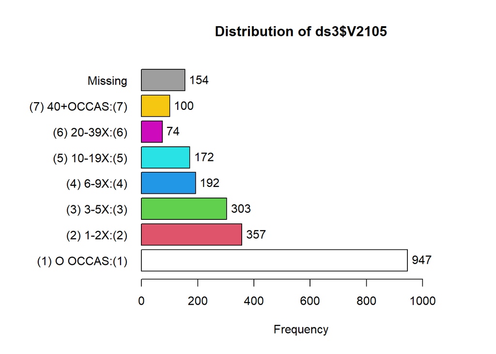

```
## ds3$V2105 :
##                  Frequency   %(NA+) cum.%(NA+)   %(NA-) cum.%(NA-)
## (1) O OCCAS:(1)        947     41.2       41.2     44.1       44.1
## (2) 1-2X:(2)           357     15.5       56.7     16.6       60.8
## (3) 3-5X:(3)           303     13.2       69.9     14.1       74.9
## (4) 6-9X:(4)           192      8.4       78.3      9.0       83.9
## (5) 10-19X:(5)         172      7.5       85.7      8.0       91.9
## (6) 20-39X:(6)          74      3.2       89.0      3.4       95.3
## (7) 40+OCCAS:(7)       100      4.3       93.3      4.7      100.0
## NA's                   154      6.7      100.0      0.0      100.0
##   Total               2299    100.0      100.0    100.0      100.0
```

```r
tab1(ds3$V2105, cum.percent = TRUE)
```

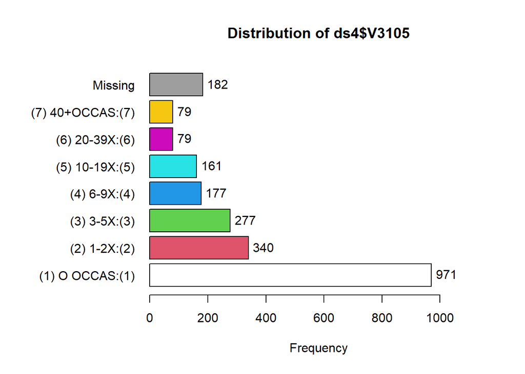

```
## ds4$V3105 :
##                  Frequency   %(NA+) cum.%(NA+)   %(NA-) cum.%(NA-)
## (1) O OCCAS:(1)        971     42.9       42.9     46.6       46.6
## (2) 1-2X:(2)           340     15.0       57.9     16.3       62.9
## (3) 3-5X:(3)           277     12.2       70.1     13.3       76.2
## (4) 6-9X:(4)           177      7.8       77.9      8.5       84.7
## (5) 10-19X:(5)         161      7.1       85.0      7.7       92.4
## (6) 20-39X:(6)          79      3.5       88.5      3.8       96.2
## (7) 40+OCCAS:(7)        79      3.5       92.0      3.8      100.0
## NA's                   182      8.0      100.0      0.0      100.0
##   Total               2266    100.0      100.0    100.0      100.0
```

```r
tab1(ds4$V3105, cum.percent = TRUE)
```

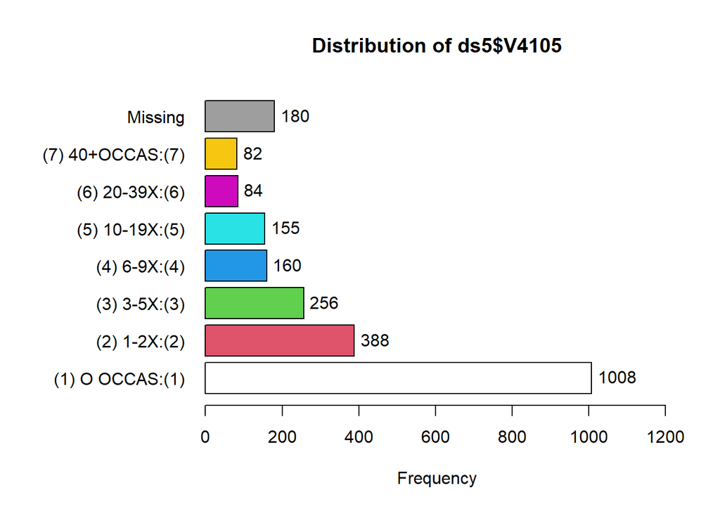

```
## ds5$V4105 :
##                  Frequency   %(NA+) cum.%(NA+)   %(NA-) cum.%(NA-)
## (1) O OCCAS:(1)       1008     43.6       43.6     47.3       47.3
## (2) 1-2X:(2)           388     16.8       60.4     18.2       65.4
## (3) 3-5X:(3)           256     11.1       71.4     12.0       77.4
## (4) 6-9X:(4)           160      6.9       78.3      7.5       85.0
## (5) 10-19X:(5)         155      6.7       85.0      7.3       92.2
## (6) 20-39X:(6)          84      3.6       88.7      3.9       96.2
## (7) 40+OCCAS:(7)        82      3.5       92.2      3.8      100.0
## NA's                   180      7.8      100.0      0.0      100.0
##   Total               2313    100.0      100.0    100.0      100.0
```

```r
tab1(ds5$V4105, cum.percent = TRUE)
```

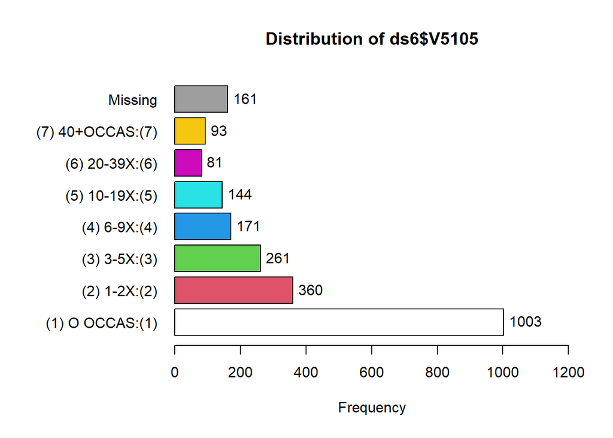

```
## ds6$V5105 :
##                  Frequency   %(NA+) cum.%(NA+)   %(NA-) cum.%(NA-)
## (1) O OCCAS:(1)       1003     44.1       44.1     47.5       47.5
## (2) 1-2X:(2)           360     15.8       59.9     17.0       64.5
## (3) 3-5X:(3)           261     11.5       71.4     12.4       76.9
## (4) 6-9X:(4)           171      7.5       78.9      8.1       85.0
## (5) 10-19X:(5)         144      6.3       85.3      6.8       91.8
## (6) 20-39X:(6)          81      3.6       88.8      3.8       95.6
## (7) 40+OCCAS:(7)        93      4.1       92.9      4.4      100.0
## NA's                   161      7.1      100.0      0.0      100.0
##   Total               2274    100.0      100.0    100.0      100.0
```

```r
tab1(ds6$V5105, cum.percent = TRUE)
```

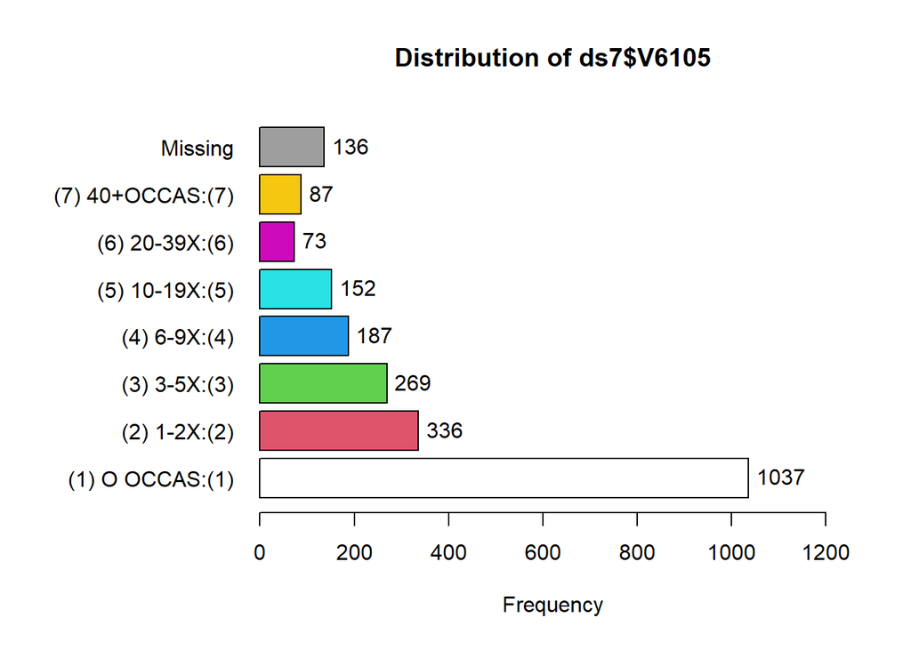

```
## ds7$V6105 :
##                  Frequency   %(NA+) cum.%(NA+)   %(NA-) cum.%(NA-)
## (1) O OCCAS:(1)       1037     45.5       45.5     48.4       48.4
## (2) 1-2X:(2)           336     14.8       60.3     15.7       64.1
## (3) 3-5X:(3)           269     11.8       72.1     12.6       76.7
## (4) 6-9X:(4)           187      8.2       80.3      8.7       85.4
## (5) 10-19X:(5)         152      6.7       87.0      7.1       92.5
## (6) 20-39X:(6)          73      3.2       90.2      3.4       95.9
## (7) 40+OCCAS:(7)        87      3.8       94.0      4.1      100.0
## NA's                   136      6.0      100.0      0.0      100.0
##   Total               2277    100.0      100.0    100.0      100.0
```

```r
tab1(ds7$V6105, cum.percent = TRUE)
```

### 00860:#XMJ+HS/LAST12MO

On how many occasions (if any) have you used marijuana (grass, pot) or hashish (hash, hash oil) . . . during the last 12 months?

[For form 1, item is recoded from separate marijuana and hashish questions, and “Dope” is given as another example of what marijuana is called.]

1=“0 Occasions” 2=“1-2 Occasions” 3=“3-5 Occasions” 4=“6-9 Occasions” 5=“10-19 Occasions” 6=“20-39 Occasions” 7=“40 or More”

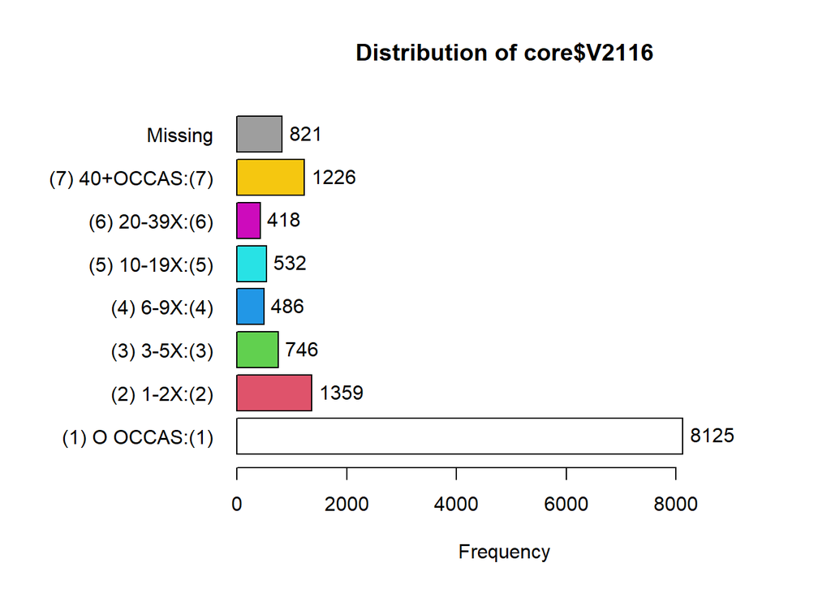

```
## core$V2116 :
##                  Frequency   %(NA+) cum.%(NA+)   %(NA-) cum.%(NA-)
## (1) O OCCAS:(1)       8125     59.3       59.3     63.0       63.0
## (2) 1-2X:(2)          1359      9.9       69.2     10.5       73.6
## (3) 3-5X:(3)           746      5.4       74.6      5.8       79.4
## (4) 6-9X:(4)           486      3.5       78.1      3.8       83.1
## (5) 10-19X:(5)         532      3.9       82.0      4.1       87.2
## (6) 20-39X:(6)         418      3.0       85.1      3.2       90.5
## (7) 40+OCCAS:(7)      1226      8.9       94.0      9.5      100.0
## NA's                   821      6.0      100.0      0.0      100.0
##   Total              13713    100.0      100.0    100.0      100.0
```

```r
tab1(core$V2116, cum.percent = TRUE)
```

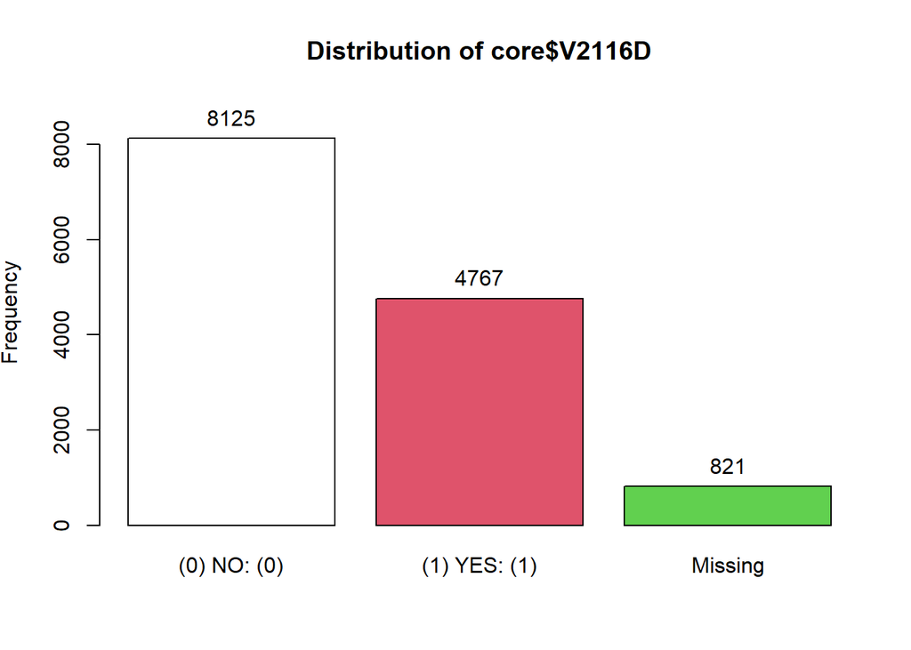

```
## core$V2116D :
##              Frequency   %(NA+) cum.%(NA+)   %(NA-) cum.%(NA-)
## (0) NO: (0)       8125     59.3       59.3       63         63
## (1) YES: (1)      4767     34.8       94.0       37        100
## NA's               821      6.0      100.0        0        100
##   Total          13713    100.0      100.0      100        100
```

```r
tab1(core$V2116D, cum.percent = TRUE)
```

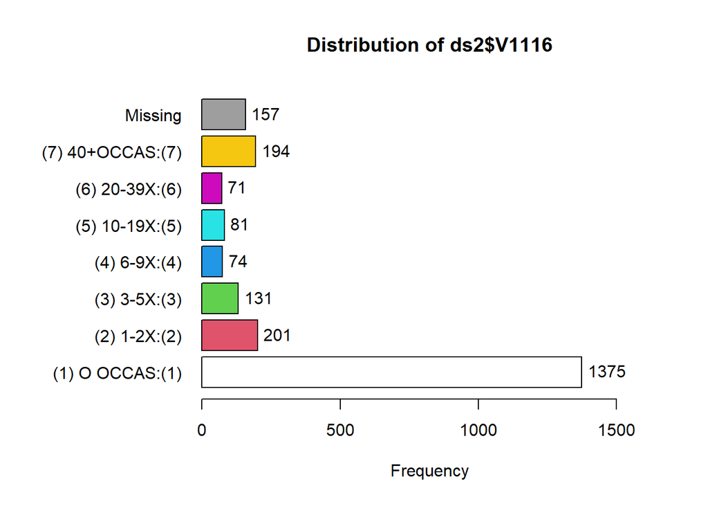

```
## ds2$V1116 :
##                  Frequency   %(NA+) cum.%(NA+)   %(NA-) cum.%(NA-)
## (1) O OCCAS:(1)       1375     60.2       60.2     64.6       64.6
## (2) 1-2X:(2)           201      8.8       69.0      9.4       74.1
## (3) 3-5X:(3)           131      5.7       74.7      6.2       80.3
## (4) 6-9X:(4)            74      3.2       78.0      3.5       83.7
## (5) 10-19X:(5)          81      3.5       81.5      3.8       87.5
## (6) 20-39X:(6)          71      3.1       84.6      3.3       90.9
## (7) 40+OCCAS:(7)       194      8.5       93.1      9.1      100.0
## NA's                   157      6.9      100.0      0.0      100.0
##   Total               2284    100.0      100.0    100.0      100.0
```

```r
tab1(ds2$V1116, cum.percent = TRUE)
```

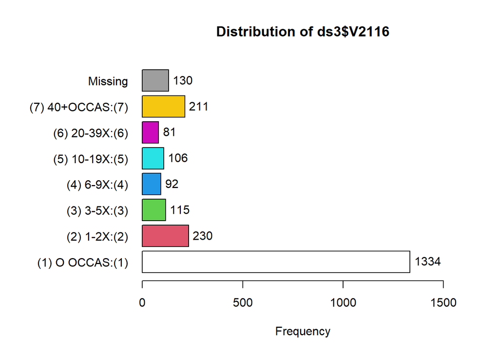

```
## ds3$V2116 :
##                  Frequency   %(NA+) cum.%(NA+)   %(NA-) cum.%(NA-)
## (1) O OCCAS:(1)       1334     58.0       58.0     61.5       61.5
## (2) 1-2X:(2)           230     10.0       68.0     10.6       72.1
## (3) 3-5X:(3)           115      5.0       73.0      5.3       77.4
## (4) 6-9X:(4)            92      4.0       77.0      4.2       81.7
## (5) 10-19X:(5)         106      4.6       81.6      4.9       86.5
## (6) 20-39X:(6)          81      3.5       85.2      3.7       90.3
## (7) 40+OCCAS:(7)       211      9.2       94.3      9.7      100.0
## NA's                   130      5.7      100.0      0.0      100.0
##   Total               2299    100.0      100.0    100.0      100.0
```

```r
tab1(ds3$V2116, cum.percent = TRUE)
```

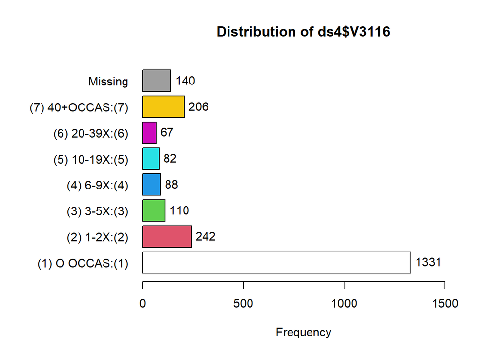

```
## ds4$V3116 :
##                  Frequency   %(NA+) cum.%(NA+)   %(NA-) cum.%(NA-)
## (1) O OCCAS:(1)       1331     58.7       58.7     62.6       62.6
## (2) 1-2X:(2)           242     10.7       69.4     11.4       74.0
## (3) 3-5X:(3)           110      4.9       74.3      5.2       79.2
## (4) 6-9X:(4)            88      3.9       78.2      4.1       83.3
## (5) 10-19X:(5)          82      3.6       81.8      3.9       87.2
## (6) 20-39X:(6)          67      3.0       84.7      3.2       90.3
## (7) 40+OCCAS:(7)       206      9.1       93.8      9.7      100.0
## NA's                   140      6.2      100.0      0.0      100.0
##   Total               2266    100.0      100.0    100.0      100.0
```

```r
tab1(ds4$V3116, cum.percent = TRUE)
```

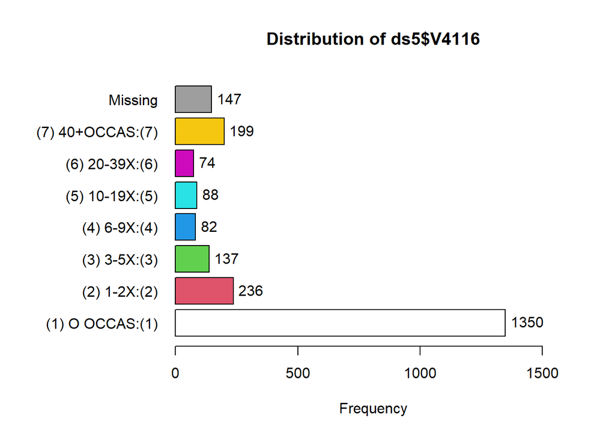

```
## ds5$V4116 :
##                  Frequency   %(NA+) cum.%(NA+)   %(NA-) cum.%(NA-)
## (1) O OCCAS:(1)       1350     58.4       58.4     62.3       62.3
## (2) 1-2X:(2)           236     10.2       68.6     10.9       73.2
## (3) 3-5X:(3)           137      5.9       74.5      6.3       79.5
## (4) 6-9X:(4)            82      3.5       78.0      3.8       83.3
## (5) 10-19X:(5)          88      3.8       81.8      4.1       87.4
## (6) 20-39X:(6)          74      3.2       85.0      3.4       90.8
## (7) 40+OCCAS:(7)       199      8.6       93.6      9.2      100.0
## NA's                   147      6.4      100.0      0.0      100.0
##   Total               2313    100.0      100.0    100.0      100.0
```

```r
tab1(ds5$V4116, cum.percent = TRUE)
```

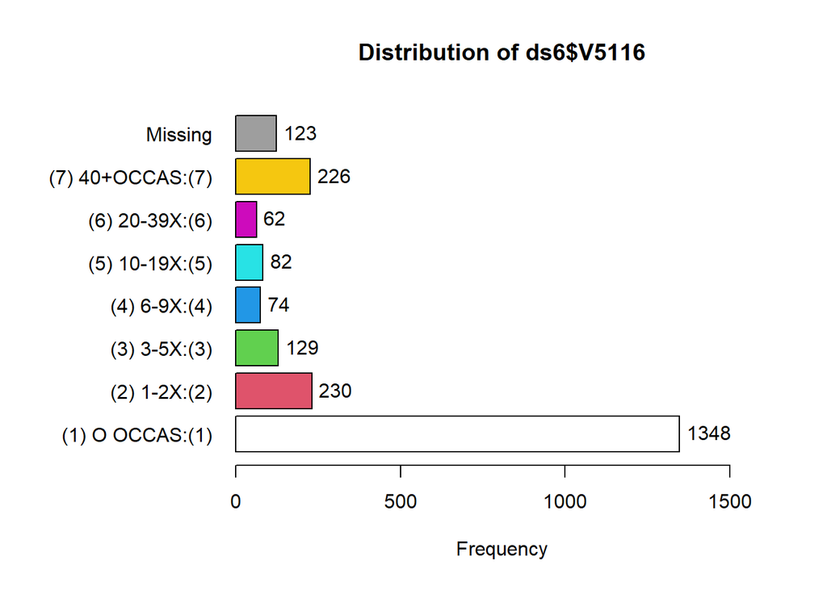

```
## ds6$V5116 :
##                  Frequency   %(NA+) cum.%(NA+)   %(NA-) cum.%(NA-)
## (1) O OCCAS:(1)       1348     59.3       59.3     62.7       62.7
## (2) 1-2X:(2)           230     10.1       69.4     10.7       73.4
## (3) 3-5X:(3)           129      5.7       75.1      6.0       79.4
## (4) 6-9X:(4)            74      3.3       78.3      3.4       82.8
## (5) 10-19X:(5)          82      3.6       81.9      3.8       86.6
## (6) 20-39X:(6)          62      2.7       84.7      2.9       89.5
## (7) 40+OCCAS:(7)       226      9.9       94.6     10.5      100.0
## NA's                   123      5.4      100.0      0.0      100.0
##   Total               2274    100.0      100.0    100.0      100.0
```

```r
tab1(ds6$V5116, cum.percent = TRUE)
```

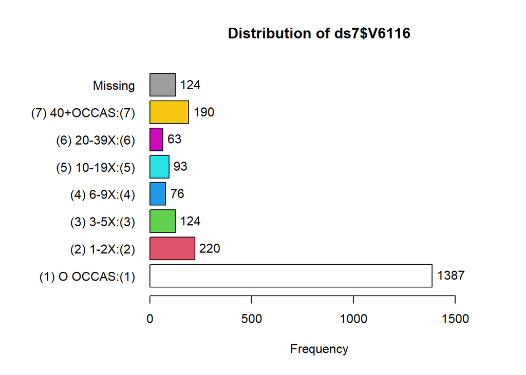

```
## ds7$V6116 :
##                  Frequency   %(NA+) cum.%(NA+)   %(NA-) cum.%(NA-)
## (1) O OCCAS:(1)       1387     60.9       60.9     64.4       64.4
## (2) 1-2X:(2)           220      9.7       70.6     10.2       74.6
## (3) 3-5X:(3)           124      5.4       76.0      5.8       80.4
## (4) 6-9X:(4)            76      3.3       79.4      3.5       83.9
## (5) 10-19X:(5)          93      4.1       83.4      4.3       88.2
## (6) 20-39X:(6)          63      2.8       86.2      2.9       91.2
## (7) 40+OCCAS:(7)       190      8.3       94.6      8.8      100.0
## NA's                   124      5.4      100.0      0.0      100.0
##   Total               2277    100.0      100.0    100.0      100.0
```

```r
tab1(ds7$V6116, cum.percent = TRUE)
```

### 00900:#X LSD/LAST 12MO

On how many occasions (if any) have you used LSD (“acid”) . . . during the last 12 months?

[Worded slightly differently in form 1; see form 1 codebook.]

1=“0 Occasions” 2=“1-2 Occasions” 3=“3-5 Occasions” 4=“6-9 Occasions” 5=“10-19 Occasions” 6=“20-39 Occasions” 7=“40 or More”

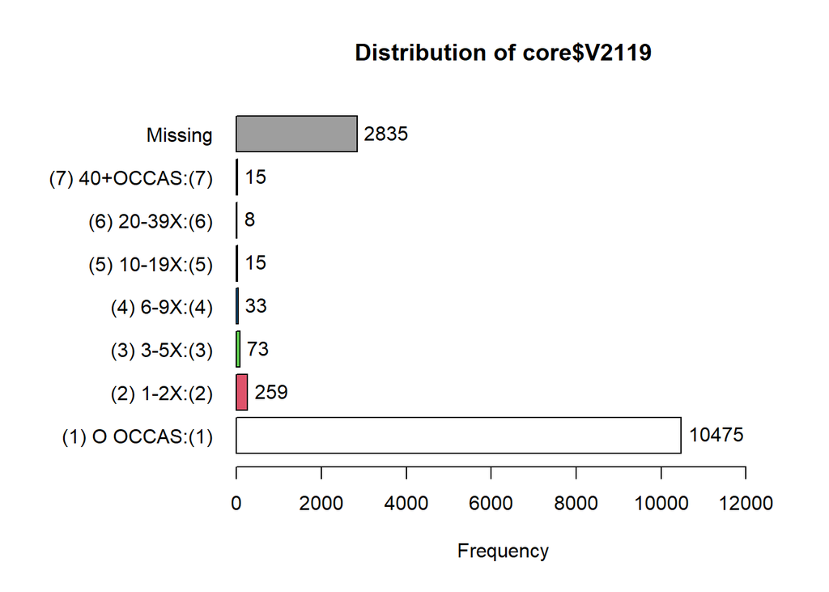

```
## core$V2119 :
##                  Frequency   %(NA+) cum.%(NA+)   %(NA-) cum.%(NA-)
## (1) O OCCAS:(1)      10475     76.4       76.4     96.3       96.3
## (2) 1-2X:(2)           259      1.9       78.3      2.4       98.7
## (3) 3-5X:(3)            73      0.5       78.8      0.7       99.3
## (4) 6-9X:(4)            33      0.2       79.0      0.3       99.7
## (5) 10-19X:(5)          15      0.1       79.2      0.1       99.8
## (6) 20-39X:(6)           8      0.1       79.2      0.1       99.9
## (7) 40+OCCAS:(7)        15      0.1       79.3      0.1      100.0
## NA's                  2835     20.7      100.0      0.0      100.0
##   Total              13713    100.0      100.0    100.0      100.0
```

```r
tab1(core$V2119, cum.percent = TRUE)
```

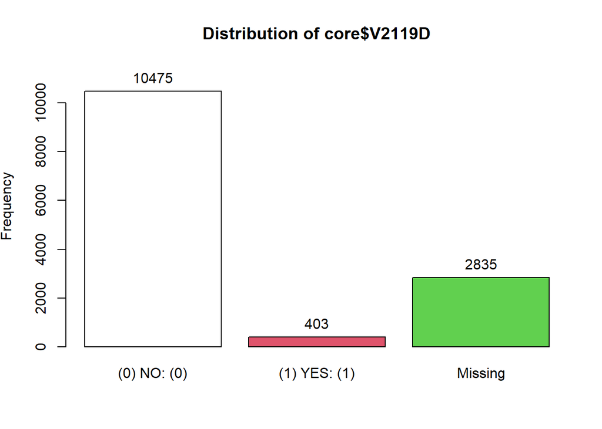

```
## core$V2119D :
##              Frequency   %(NA+) cum.%(NA+)   %(NA-) cum.%(NA-)
## (0) NO: (0)      10475     76.4       76.4     96.3       96.3
## (1) YES: (1)       403      2.9       79.3      3.7      100.0
## NA's              2835     20.7      100.0      0.0      100.0
##   Total          13713    100.0      100.0    100.0      100.0
```

```r
tab1(core$V2119D, cum.percent = TRUE)
```

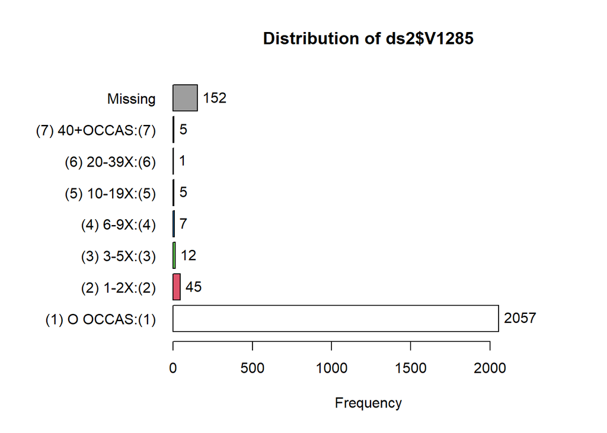

```
## ds2$V1285 :
##                  Frequency   %(NA+) cum.%(NA+)   %(NA-) cum.%(NA-)
## (1) O OCCAS:(1)       2057     90.1       90.1     96.5       96.5
## (2) 1-2X:(2)            45      2.0       92.0      2.1       98.6
## (3) 3-5X:(3)            12      0.5       92.6      0.6       99.2
## (4) 6-9X:(4)             7      0.3       92.9      0.3       99.5
## (5) 10-19X:(5)           5      0.2       93.1      0.2       99.7
## (6) 20-39X:(6)           1      0.0       93.1      0.0       99.8
## (7) 40+OCCAS:(7)         5      0.2       93.3      0.2      100.0
## NA's                   152      6.7      100.0      0.0      100.0
##   Total               2284    100.0      100.0    100.0      100.0
```

```r
tab1(ds2$V1285, cum.percent = TRUE)
```

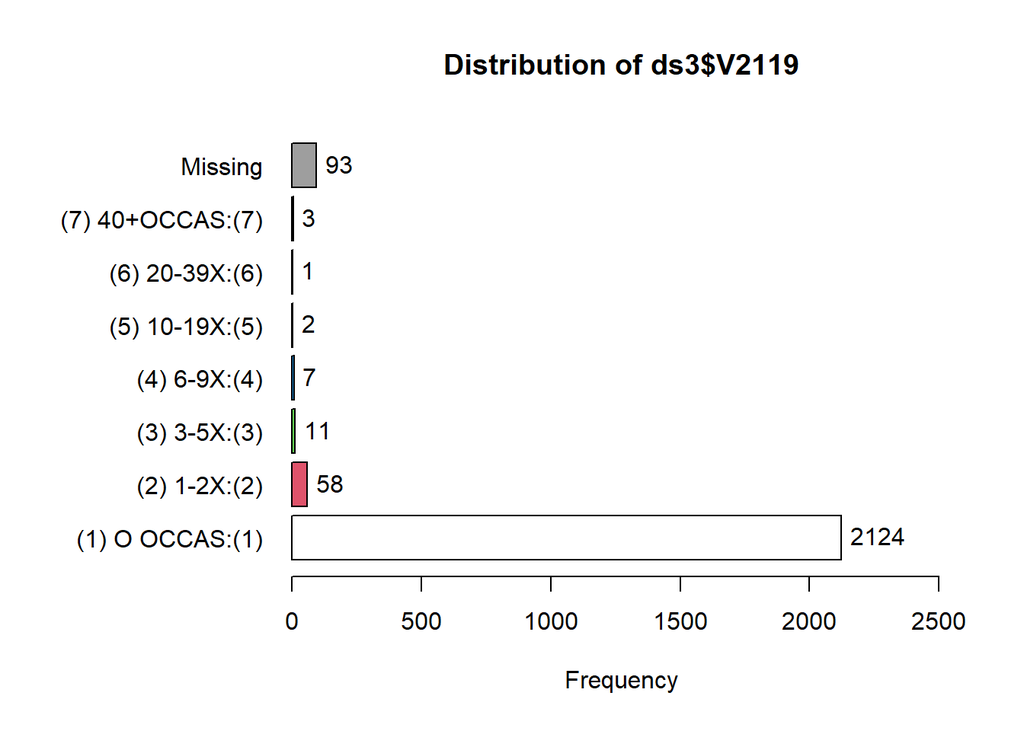

```
## ds3$V2119 :
##                  Frequency   %(NA+) cum.%(NA+)   %(NA-) cum.%(NA-)
## (1) O OCCAS:(1)       2124     92.4       92.4     96.3       96.3
## (2) 1-2X:(2)            58      2.5       94.9      2.6       98.9
## (3) 3-5X:(3)            11      0.5       95.4      0.5       99.4
## (4) 6-9X:(4)             7      0.3       95.7      0.3       99.7
## (5) 10-19X:(5)           2      0.1       95.8      0.1       99.8
## (6) 20-39X:(6)           1      0.0       95.8      0.0       99.9
## (7) 40+OCCAS:(7)         3      0.1       96.0      0.1      100.0
## NA's                    93      4.0      100.0      0.0      100.0
##   Total               2299    100.0      100.0    100.0      100.0
```

```r
tab1(ds3$V2119, cum.percent = TRUE)
```

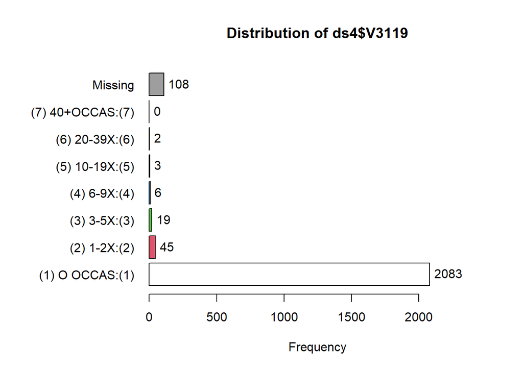

```
## ds4$V3119 :
##                  Frequency   %(NA+) cum.%(NA+)   %(NA-) cum.%(NA-)
## (1) O OCCAS:(1)       2083     91.9       91.9     96.5       96.5
## (2) 1-2X:(2)            45      2.0       93.9      2.1       98.6
## (3) 3-5X:(3)            19      0.8       94.7      0.9       99.5
## (4) 6-9X:(4)             6      0.3       95.0      0.3       99.8
## (5) 10-19X:(5)           3      0.1       95.1      0.1       99.9
## (6) 20-39X:(6)           2      0.1       95.2      0.1      100.0
## (7) 40+OCCAS:(7)         0      0.0       95.2      0.0      100.0
## NA's                   108      4.8      100.0      0.0      100.0
##   Total               2266    100.0      100.0    100.0      100.0
```

```r
tab1(ds4$V3119, cum.percent = TRUE)
```

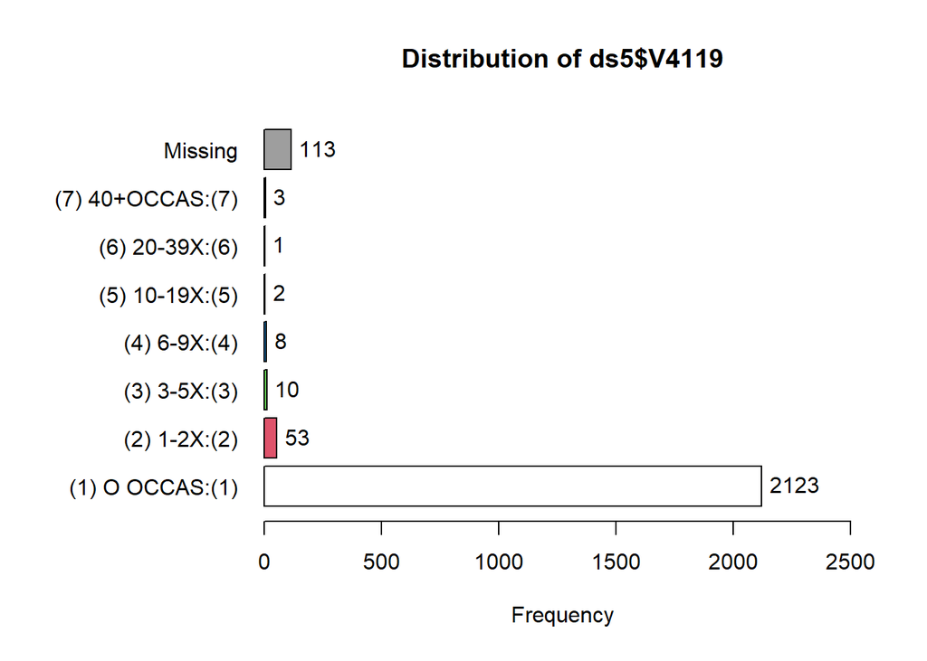

```
## ds5$V4119 :
##                  Frequency   %(NA+) cum.%(NA+)   %(NA-) cum.%(NA-)
## (1) O OCCAS:(1)       2123     91.8       91.8     96.5       96.5
## (2) 1-2X:(2)            53      2.3       94.1      2.4       98.9
## (3) 3-5X:(3)            10      0.4       94.5      0.5       99.4
## (4) 6-9X:(4)             8      0.3       94.9      0.4       99.7
## (5) 10-19X:(5)           2      0.1       94.9      0.1       99.8
## (6) 20-39X:(6)           1      0.0       95.0      0.0       99.9
## (7) 40+OCCAS:(7)         3      0.1       95.1      0.1      100.0
## NA's                   113      4.9      100.0      0.0      100.0
##   Total               2313    100.0      100.0    100.0      100.0
```

```r
tab1(ds5$V4119, cum.percent = TRUE)
```

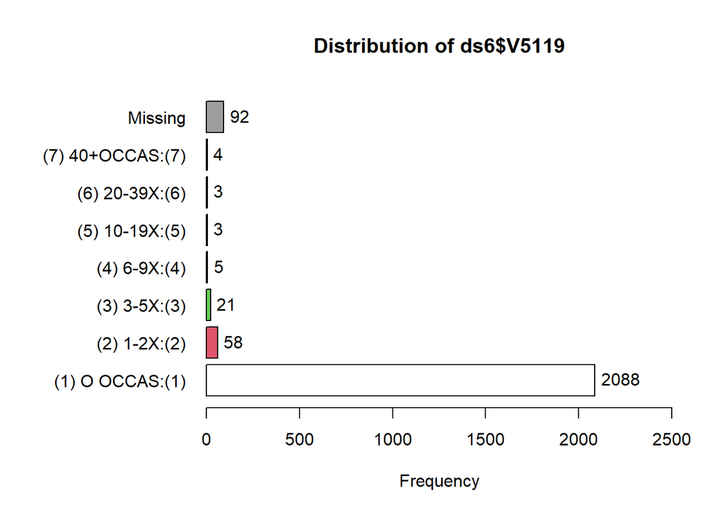

```
## ds6$V5119 :
##                  Frequency   %(NA+) cum.%(NA+)   %(NA-) cum.%(NA-)
## (1) O OCCAS:(1)       2088     91.8       91.8     95.7       95.7
## (2) 1-2X:(2)            58      2.6       94.4      2.7       98.4
## (3) 3-5X:(3)            21      0.9       95.3      1.0       99.3
## (4) 6-9X:(4)             5      0.2       95.5      0.2       99.5
## (5) 10-19X:(5)           3      0.1       95.6      0.1       99.7
## (6) 20-39X:(6)           3      0.1       95.8      0.1       99.8
## (7) 40+OCCAS:(7)         4      0.2       96.0      0.2      100.0
## NA's                    92      4.0      100.0      0.0      100.0
##   Total               2274    100.0      100.0    100.0      100.0
```

```r
tab1(ds6$V5119, cum.percent = TRUE)
```

### 00960:#X COKE/LAST12MO

On how many occasions (if any) have you taken cocaine (sometimes called “coke”, “crack”, “rock”) . . . during last 12 months?

[For questionnaire forms 1, 3, 4, and 6, item is recoded from separate questions about “crack” (items 22260-22280) and other forms of cocaine (items 22320-22340).]

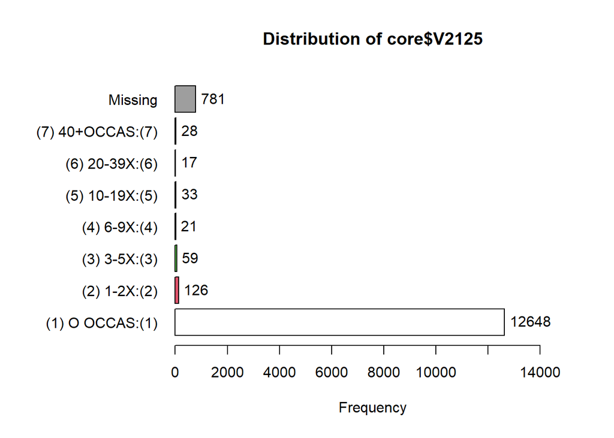

```
## core$V2125 :
##                  Frequency   %(NA+) cum.%(NA+)   %(NA-) cum.%(NA-)
## (1) O OCCAS:(1)      12648     92.2       92.2     97.8       97.8
## (2) 1-2X:(2)           126      0.9       93.2      1.0       98.8
## (3) 3-5X:(3)            59      0.4       93.6      0.5       99.2
## (4) 6-9X:(4)            21      0.2       93.7      0.2       99.4
## (5) 10-19X:(5)          33      0.2       94.0      0.3       99.7
## (6) 20-39X:(6)          17      0.1       94.1      0.1       99.8
## (7) 40+OCCAS:(7)        28      0.2       94.3      0.2      100.0
## NA's                   781      5.7      100.0      0.0      100.0
##   Total              13713    100.0      100.0    100.0      100.0
```

```r
tab1(core$V2125, cum.percent = TRUE)
```

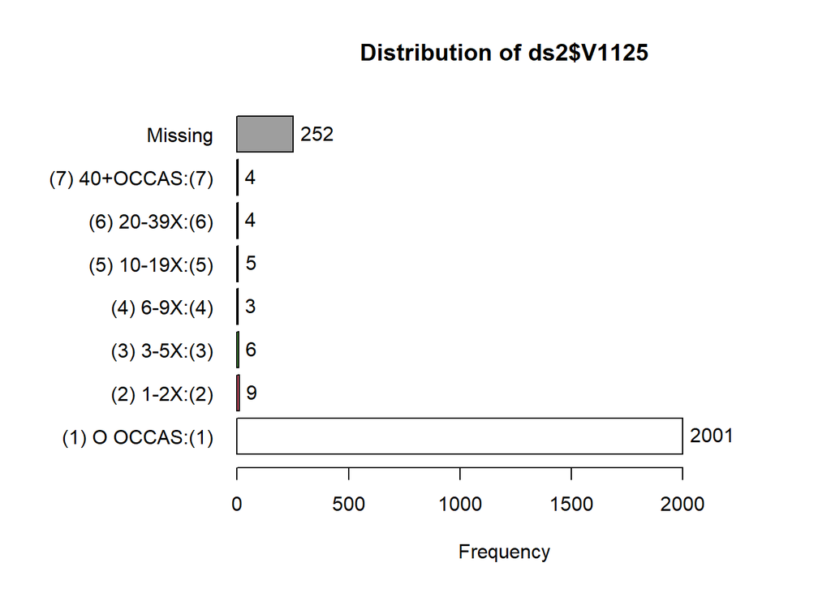

```
## ds2$V1125 :
##                  Frequency   %(NA+) cum.%(NA+)   %(NA-) cum.%(NA-)
## (1) O OCCAS:(1)       2001     87.6       87.6     98.5       98.5
## (2) 1-2X:(2)             9      0.4       88.0      0.4       98.9
## (3) 3-5X:(3)             6      0.3       88.3      0.3       99.2
## (4) 6-9X:(4)             3      0.1       88.4      0.1       99.4
## (5) 10-19X:(5)           5      0.2       88.6      0.2       99.6
## (6) 20-39X:(6)           4      0.2       88.8      0.2       99.8
## (7) 40+OCCAS:(7)         4      0.2       89.0      0.2      100.0
## NA's                   252     11.0      100.0      0.0      100.0
##   Total               2284    100.0      100.0    100.0      100.0
```

```r
tab1(ds2$V1125, cum.percent = TRUE)
```

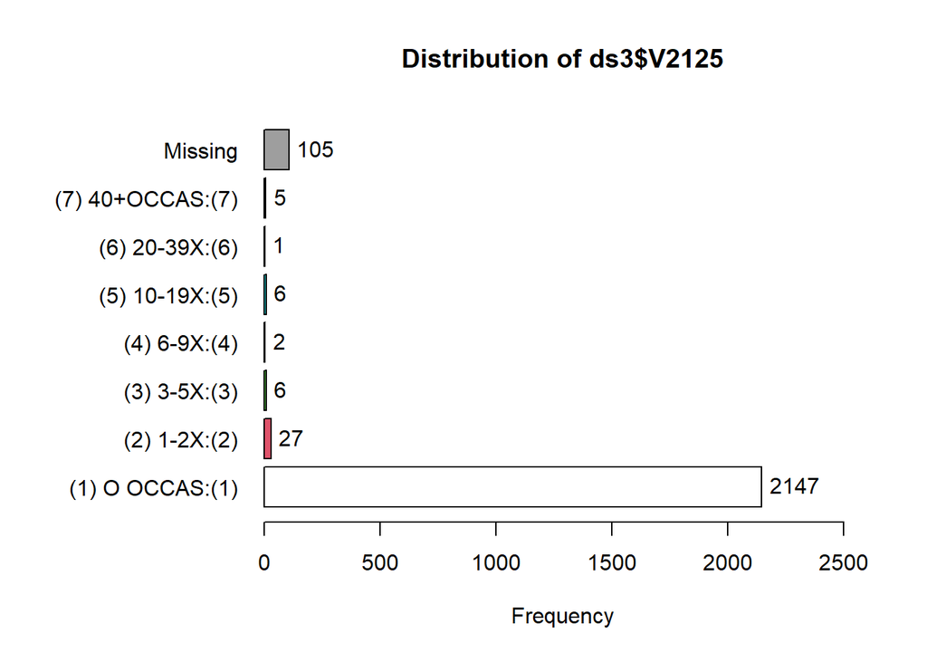

```
## ds3$V2125 :
##                  Frequency   %(NA+) cum.%(NA+)   %(NA-) cum.%(NA-)
## (1) O OCCAS:(1)       2147     93.4       93.4     97.9       97.9
## (2) 1-2X:(2)            27      1.2       94.6      1.2       99.1
## (3) 3-5X:(3)             6      0.3       94.8      0.3       99.4
## (4) 6-9X:(4)             2      0.1       94.9      0.1       99.5
## (5) 10-19X:(5)           6      0.3       95.2      0.3       99.7
## (6) 20-39X:(6)           1      0.0       95.2      0.0       99.8
## (7) 40+OCCAS:(7)         5      0.2       95.4      0.2      100.0
## NA's                   105      4.6      100.0      0.0      100.0
##   Total               2299    100.0      100.0    100.0      100.0
```

```r
tab1(ds3$V2125, cum.percent = TRUE)
```

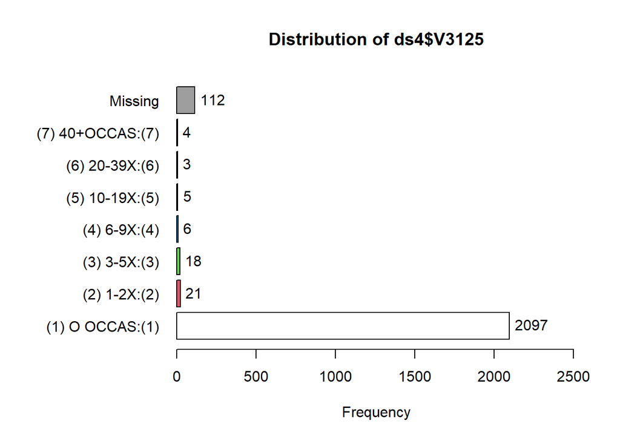

```
## ds4$V3125 :
##                  Frequency   %(NA+) cum.%(NA+)   %(NA-) cum.%(NA-)
## (1) O OCCAS:(1)       2097     92.5       92.5     97.4       97.4
## (2) 1-2X:(2)            21      0.9       93.5      1.0       98.3
## (3) 3-5X:(3)            18      0.8       94.3      0.8       99.2
## (4) 6-9X:(4)             6      0.3       94.5      0.3       99.4
## (5) 10-19X:(5)           5      0.2       94.7      0.2       99.7
## (6) 20-39X:(6)           3      0.1       94.9      0.1       99.8
## (7) 40+OCCAS:(7)         4      0.2       95.1      0.2      100.0
## NA's                   112      4.9      100.0      0.0      100.0
##   Total               2266    100.0      100.0    100.0      100.0
```

```r
tab1(ds4$V3125, cum.percent = TRUE)
```

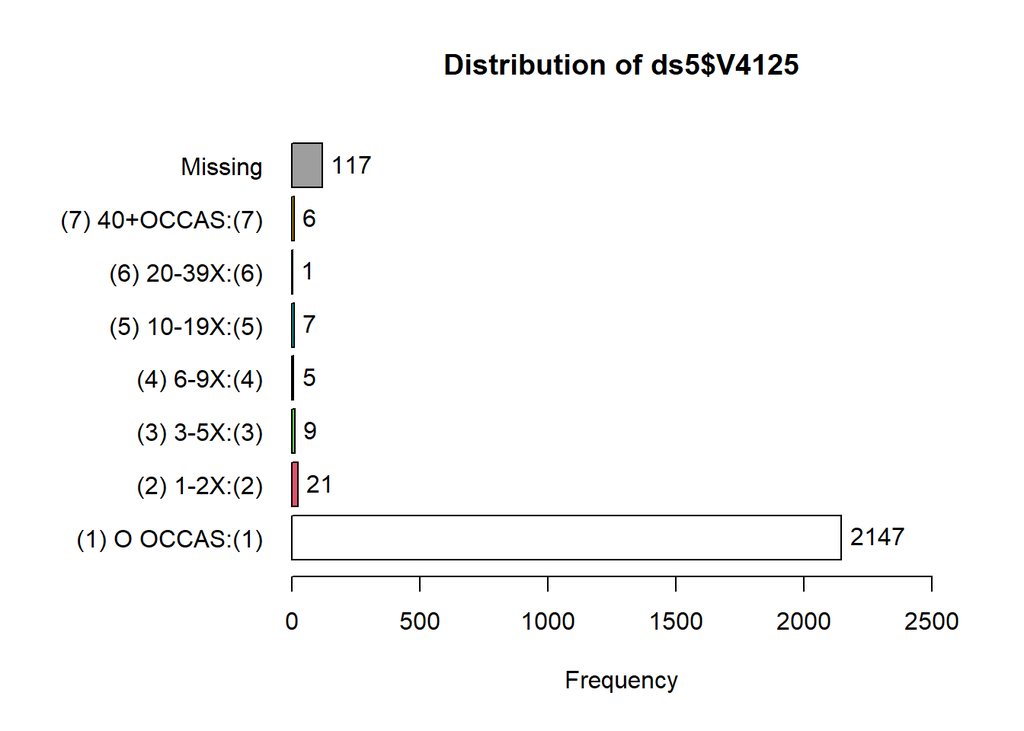

```
## ds5$V4125 :
##                  Frequency   %(NA+) cum.%(NA+)   %(NA-) cum.%(NA-)
## (1) O OCCAS:(1)       2147     92.8       92.8     97.8       97.8
## (2) 1-2X:(2)            21      0.9       93.7      1.0       98.7
## (3) 3-5X:(3)             9      0.4       94.1      0.4       99.1
## (4) 6-9X:(4)             5      0.2       94.3      0.2       99.4
## (5) 10-19X:(5)           7      0.3       94.6      0.3       99.7
## (6) 20-39X:(6)           1      0.0       94.7      0.0       99.7
## (7) 40+OCCAS:(7)         6      0.3       94.9      0.3      100.0
## NA's                   117      5.1      100.0      0.0      100.0
##   Total               2313    100.0      100.0    100.0      100.0
```

```r
tab1(ds5$V4125, cum.percent = TRUE)
```

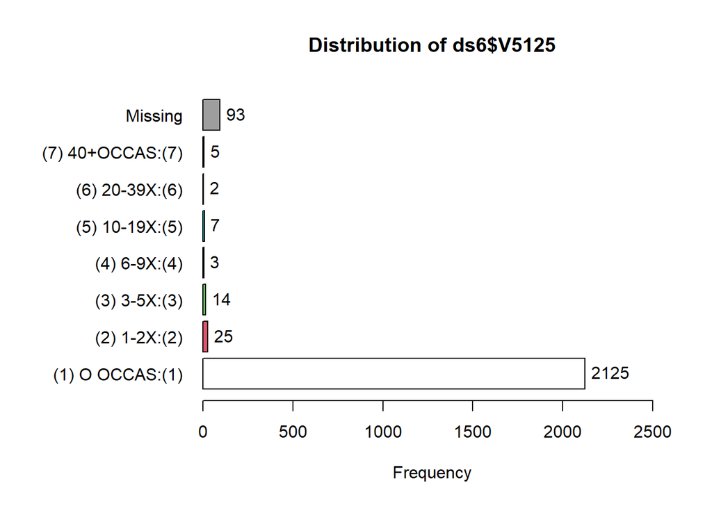

```
## ds6$V5125 :
##                  Frequency   %(NA+) cum.%(NA+)   %(NA-) cum.%(NA-)
## (1) O OCCAS:(1)       2125     93.4       93.4     97.4       97.4
## (2) 1-2X:(2)            25      1.1       94.5      1.1       98.6
## (3) 3-5X:(3)            14      0.6       95.2      0.6       99.2
## (4) 6-9X:(4)             3      0.1       95.3      0.1       99.4
## (5) 10-19X:(5)           7      0.3       95.6      0.3       99.7
## (6) 20-39X:(6)           2      0.1       95.7      0.1       99.8
## (7) 40+OCCAS:(7)         5      0.2       95.9      0.2      100.0
## NA's                    93      4.1      100.0      0.0      100.0
##   Total               2274    100.0      100.0    100.0      100.0
```

```r
tab1(ds6$V5125, cum.percent = TRUE)
```

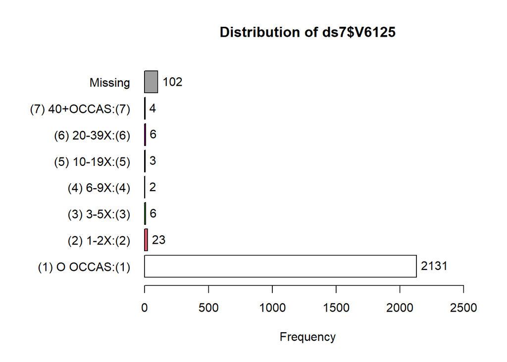

```
## ds7$V6125 :
##                  Frequency   %(NA+) cum.%(NA+)   %(NA-) cum.%(NA-)
## (1) O OCCAS:(1)       2131     93.6       93.6     98.0       98.0
## (2) 1-2X:(2)            23      1.0       94.6      1.1       99.0
## (3) 3-5X:(3)             6      0.3       94.9      0.3       99.3
## (4) 6-9X:(4)             2      0.1       94.9      0.1       99.4
## (5) 10-19X:(5)           3      0.1       95.1      0.1       99.5
## (6) 20-39X:(6)           6      0.3       95.3      0.3       99.8
## (7) 40+OCCAS:(7)         4      0.2       95.5      0.2      100.0
## NA's                   102      4.5      100.0      0.0      100.0
##   Total               2277    100.0      100.0    100.0      100.0
```

```r
tab1(ds7$V6125, cum.percent = TRUE)
```

### 00990:#X AMPH/LAST12MO

{Amphetamines are sometimes prescribed by doctors for people who have trouble paying attention, are hyperactive, have ADHD, or have trouble staying awake. They are sometimes called uppers, ups, pep pills, and include drugs like Adderall and Ritalin. Drugstores are not supposed to sell them without a prescription from a doctor. Amphetamines

do NOT include any nonprescription drugs, such as over-the-counter diet pills or stay-awake pills.

[Questionnaire form 1 worded somewhat differently and also includes as examples: Benzedrine, Dexedrine, Methedrine, Ritalin, Adderall, Concerta, Methamphetamine, Meth or Crystal Meth (see form 1 codebook).]}

[All forms]: On how many occasions (if any) have you taken amphetamines on your own–that is, without a doctor telling you to take them . . . during the last 12 months?

1=“0 Occasions” 2=“1-2 Occasions” 3=“3-5 Occasions” 4=“6-9 Occasions” 5=“10-19 Occasions” 6=“20-39 Occasions” 7=“40 or More”

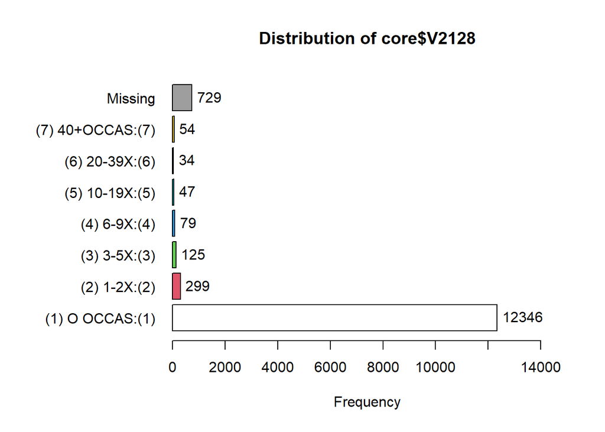

```
## core$V2128 :
##                  Frequency   %(NA+) cum.%(NA+)   %(NA-) cum.%(NA-)
## (1) O OCCAS:(1)      12346     90.0       90.0     95.1       95.1
## (2) 1-2X:(2)           299      2.2       92.2      2.3       97.4
## (3) 3-5X:(3)           125      0.9       93.1      1.0       98.4
## (4) 6-9X:(4)            79      0.6       93.7      0.6       99.0
## (5) 10-19X:(5)          47      0.3       94.0      0.4       99.3
## (6) 20-39X:(6)          34      0.2       94.3      0.3       99.6
## (7) 40+OCCAS:(7)        54      0.4       94.7      0.4      100.0
## NA's                   729      5.3      100.0      0.0      100.0
##   Total              13713    100.0      100.0    100.0      100.0
```

```r
tab1(core$V2128, cum.percent = TRUE)
```

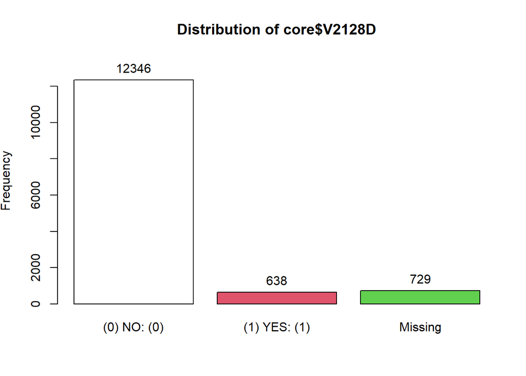

```
## core$V2128D :
##              Frequency   %(NA+) cum.%(NA+)   %(NA-) cum.%(NA-)
## (0) NO: (0)      12346     90.0       90.0     95.1       95.1
## (1) YES: (1)       638      4.7       94.7      4.9      100.0
## NA's               729      5.3      100.0      0.0      100.0
##   Total          13713    100.0      100.0    100.0      100.0
```

```r
tab1(core$V2128D, cum.percent = TRUE)
```

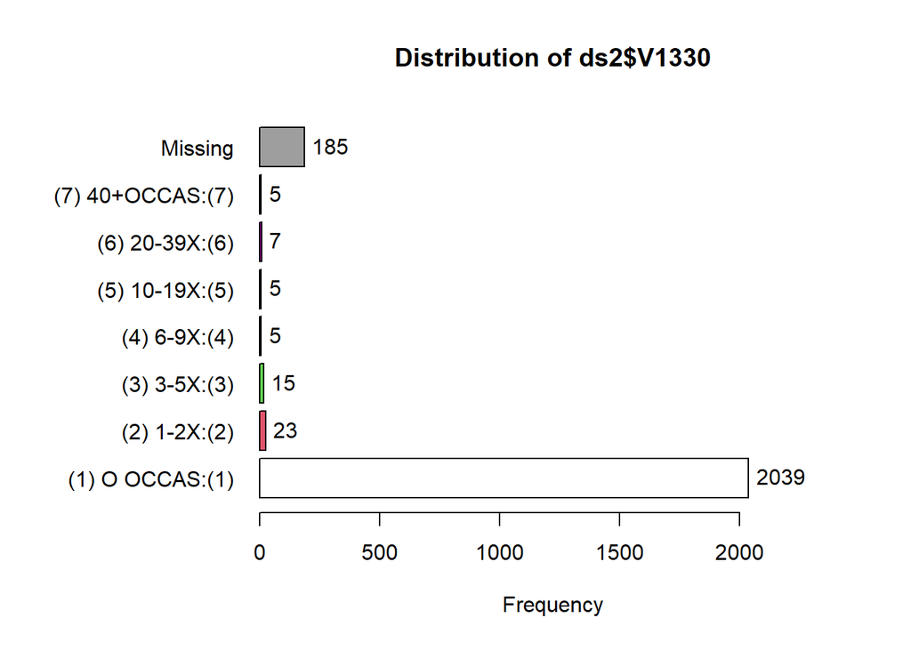

```
## ds2$V1330 :
##                  Frequency   %(NA+) cum.%(NA+)   %(NA-) cum.%(NA-)
## (1) O OCCAS:(1)       2039     89.3       89.3     97.1       97.1
## (2) 1-2X:(2)            23      1.0       90.3      1.1       98.2
## (3) 3-5X:(3)            15      0.7       90.9      0.7       99.0
## (4) 6-9X:(4)             5      0.2       91.2      0.2       99.2
## (5) 10-19X:(5)           5      0.2       91.4      0.2       99.4
## (6) 20-39X:(6)           7      0.3       91.7      0.3       99.8
## (7) 40+OCCAS:(7)         5      0.2       91.9      0.2      100.0
## NA's                   185      8.1      100.0      0.0      100.0
##   Total               2284    100.0      100.0    100.0      100.0
```

```r
tab1(ds2$V1330, cum.percent = TRUE)
```

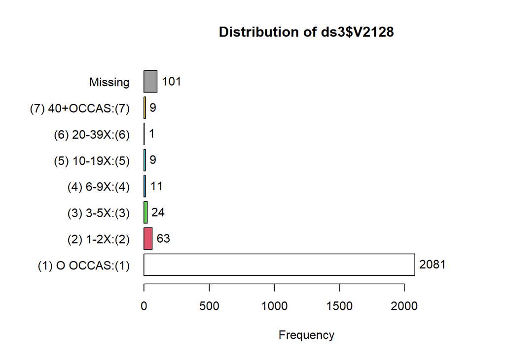

```
## ds3$V2128 :
##                  Frequency   %(NA+) cum.%(NA+)   %(NA-) cum.%(NA-)
## (1) O OCCAS:(1)       2081     90.5       90.5     94.7       94.7
## (2) 1-2X:(2)            63      2.7       93.3      2.9       97.5
## (3) 3-5X:(3)            24      1.0       94.3      1.1       98.6
## (4) 6-9X:(4)            11      0.5       94.8      0.5       99.1
## (5) 10-19X:(5)           9      0.4       95.2      0.4       99.5
## (6) 20-39X:(6)           1      0.0       95.2      0.0       99.6
## (7) 40+OCCAS:(7)         9      0.4       95.6      0.4      100.0
## NA's                   101      4.4      100.0      0.0      100.0
##   Total               2299    100.0      100.0    100.0      100.0
```

```r
tab1(ds3$V2128, cum.percent = TRUE)
```

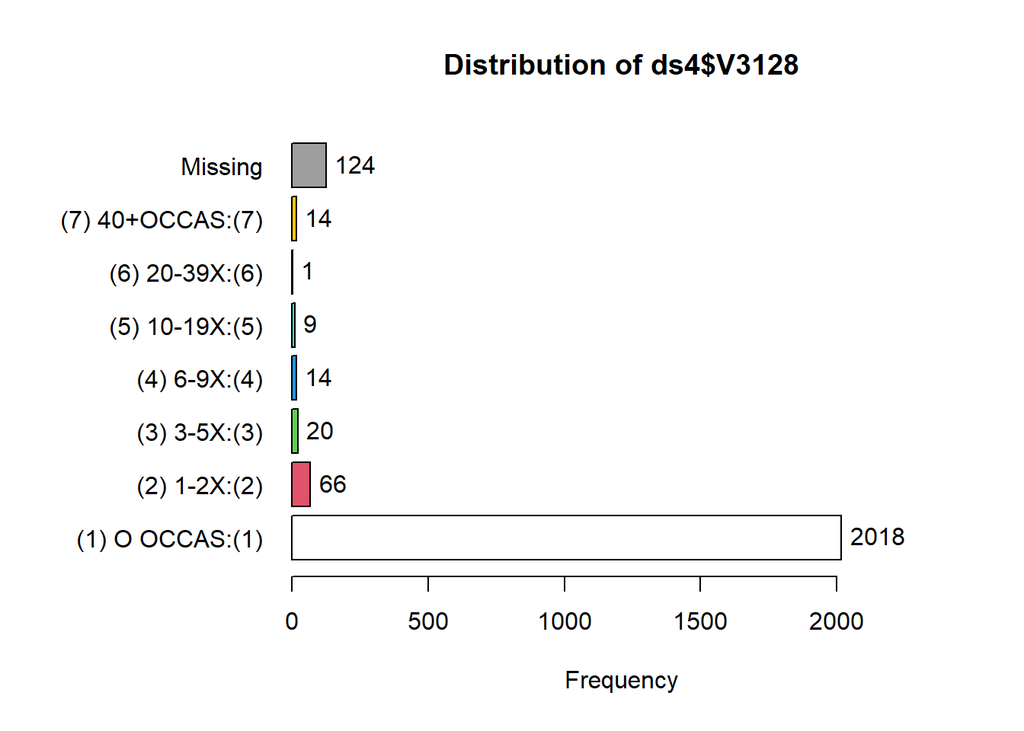

```
## ds4$V3128 :
##                  Frequency   %(NA+) cum.%(NA+)   %(NA-) cum.%(NA-)
## (1) O OCCAS:(1)       2018     89.1       89.1     94.2       94.2
## (2) 1-2X:(2)            66      2.9       92.0      3.1       97.3
## (3) 3-5X:(3)            20      0.9       92.9      0.9       98.2
## (4) 6-9X:(4)            14      0.6       93.5      0.7       98.9
## (5) 10-19X:(5)           9      0.4       93.9      0.4       99.3
## (6) 20-39X:(6)           1      0.0       93.9      0.0       99.3
## (7) 40+OCCAS:(7)        14      0.6       94.5      0.7      100.0
## NA's                   124      5.5      100.0      0.0      100.0
##   Total               2266    100.0      100.0    100.0      100.0
```

```r
tab1(ds4$V3128, cum.percent = TRUE)
```

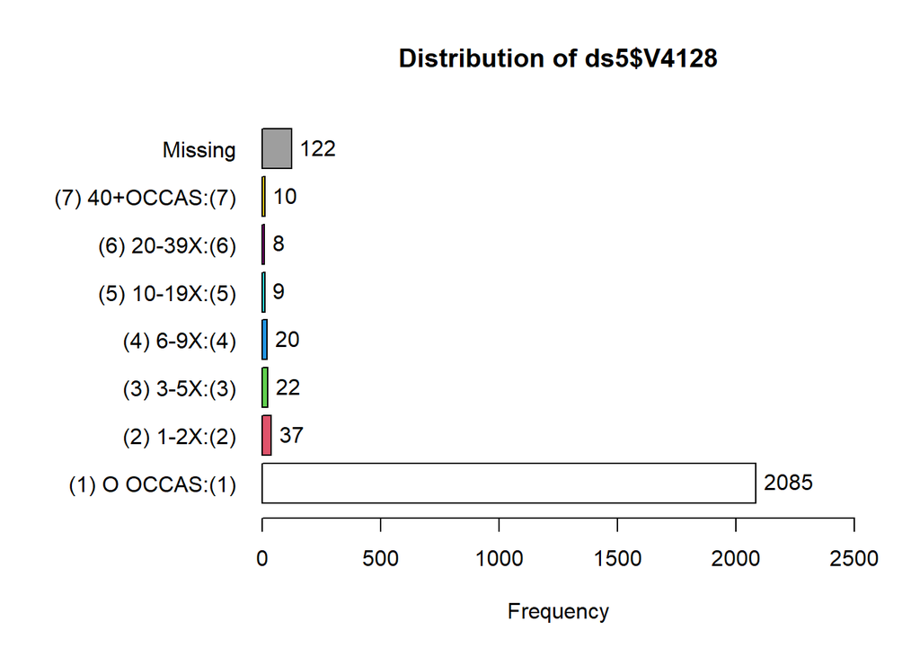

```
## ds5$V4128 :
##                  Frequency   %(NA+) cum.%(NA+)   %(NA-) cum.%(NA-)
## (1) O OCCAS:(1)       2085     90.1       90.1     95.2       95.2
## (2) 1-2X:(2)            37      1.6       91.7      1.7       96.9
## (3) 3-5X:(3)            22      1.0       92.7      1.0       97.9
## (4) 6-9X:(4)            20      0.9       93.6      0.9       98.8
## (5) 10-19X:(5)           9      0.4       93.9      0.4       99.2
## (6) 20-39X:(6)           8      0.3       94.3      0.4       99.5
## (7) 40+OCCAS:(7)        10      0.4       94.7      0.5      100.0
## NA's                   122      5.3      100.0      0.0      100.0
##   Total               2313    100.0      100.0    100.0      100.0
```

```r
tab1(ds5$V4128, cum.percent = TRUE)
```

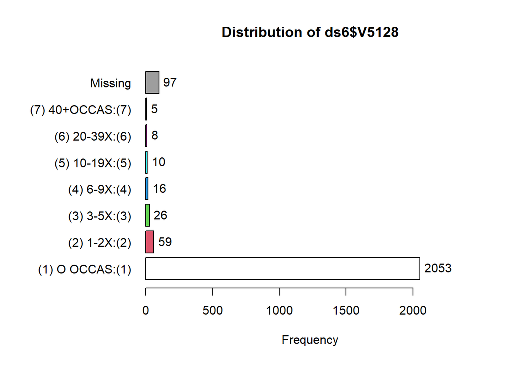

```
## ds6$V5128 :
##                  Frequency   %(NA+) cum.%(NA+)   %(NA-) cum.%(NA-)
## (1) O OCCAS:(1)       2053     90.3       90.3     94.3       94.3
## (2) 1-2X:(2)            59      2.6       92.9      2.7       97.0
## (3) 3-5X:(3)            26      1.1       94.0      1.2       98.2
## (4) 6-9X:(4)            16      0.7       94.7      0.7       98.9
## (5) 10-19X:(5)          10      0.4       95.2      0.5       99.4
## (6) 20-39X:(6)           8      0.4       95.5      0.4       99.8
## (7) 40+OCCAS:(7)         5      0.2       95.7      0.2      100.0
## NA's                    97      4.3      100.0      0.0      100.0
##   Total               2274    100.0      100.0    100.0      100.0
```

```r
tab1(ds6$V5128, cum.percent = TRUE)
```

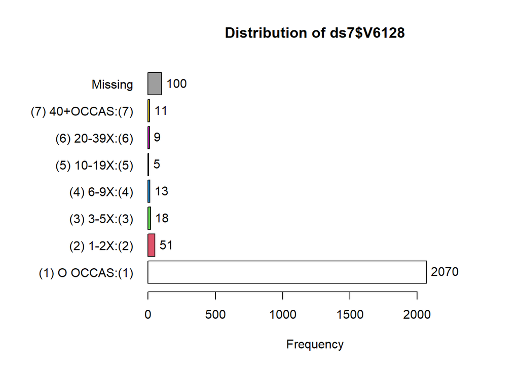

```
## ds7$V6128 :
##                  Frequency   %(NA+) cum.%(NA+)   %(NA-) cum.%(NA-)
## (1) O OCCAS:(1)       2070     90.9       90.9     95.1       95.1
## (2) 1-2X:(2)            51      2.2       93.1      2.3       97.4
## (3) 3-5X:(3)            18      0.8       93.9      0.8       98.3
## (4) 6-9X:(4)            13      0.6       94.5      0.6       98.9
## (5) 10-19X:(5)           5      0.2       94.7      0.2       99.1
## (6) 20-39X:(6)           9      0.4       95.1      0.4       99.5
## (7) 40+OCCAS:(7)        11      0.5       95.6      0.5      100.0
## NA's                   100      4.4      100.0      0.0      100.0
##   Total               2277    100.0      100.0    100.0      100.0
```

```r
tab1(ds7$V6128, cum.percent = TRUE)
```

### 01050:#X SED/BARB/LAST12MO

{Sedatives, including barbiturates, are sometimes prescribed by doctors to help people relax or get to sleep. They are sometimes called downs or downers, and include phenobarbital, Tuinal, Nembutal, and Seconal.} On how many occasions (if any) have you taken sedatives on your own–that is, without a doctor telling you to take them . . . during the last 12 months?

[Worded slightly differently in questionnaire form 1, and replaced Nembutal with Ambien, Lunesta, and Sonata as examples; see form 1 codebook.]

1=“0 Occasions” 2=“1-2 Occasions” 3=“3-5 Occasions” 4=“6-9 Occasions” 5=“10-19 Occasions” 6=“20-39 Occasions” 7=“40 or More”

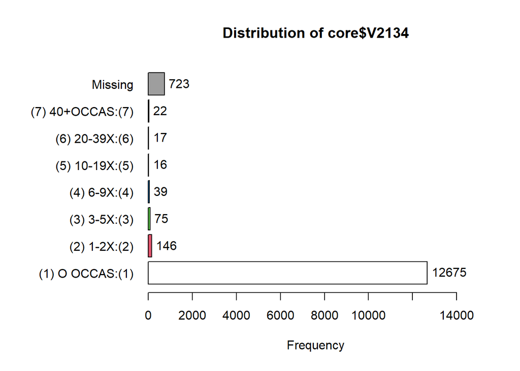

```
## core$V2134 :
##                  Frequency   %(NA+) cum.%(NA+)   %(NA-) cum.%(NA-)
## (1) O OCCAS:(1)      12675     92.4       92.4     97.6       97.6
## (2) 1-2X:(2)           146      1.1       93.5      1.1       98.7
## (3) 3-5X:(3)            75      0.5       94.0      0.6       99.3
## (4) 6-9X:(4)            39      0.3       94.3      0.3       99.6
## (5) 10-19X:(5)          16      0.1       94.4      0.1       99.7
## (6) 20-39X:(6)          17      0.1       94.6      0.1       99.8
## (7) 40+OCCAS:(7)        22      0.2       94.7      0.2      100.0
## NA's                   723      5.3      100.0      0.0      100.0
##   Total              13713    100.0      100.0    100.0      100.0
```

```r
tab1(core$V2134, cum.percent = TRUE)
```

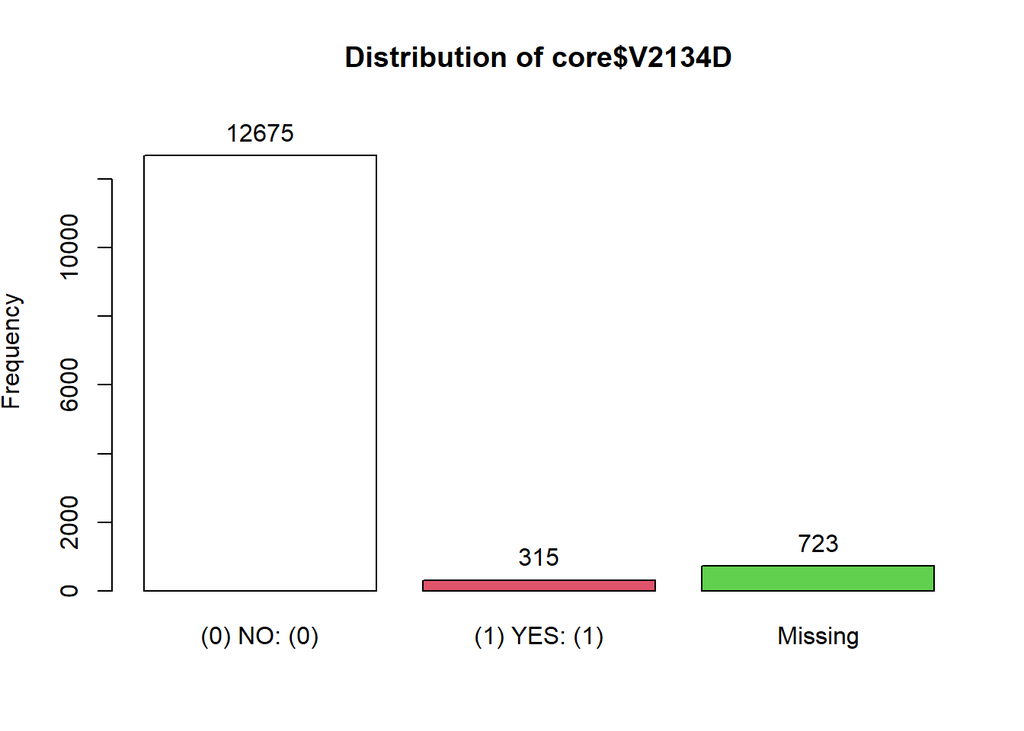

```
## core$V2134D :
##              Frequency   %(NA+) cum.%(NA+)   %(NA-) cum.%(NA-)
## (0) NO: (0)      12675     92.4       92.4     97.6       97.6
## (1) YES: (1)       315      2.3       94.7      2.4      100.0
## NA's               723      5.3      100.0      0.0      100.0
##   Total          13713    100.0      100.0    100.0      100.0
```

```r
tab1(core$V2134D, cum.percent = TRUE)
```

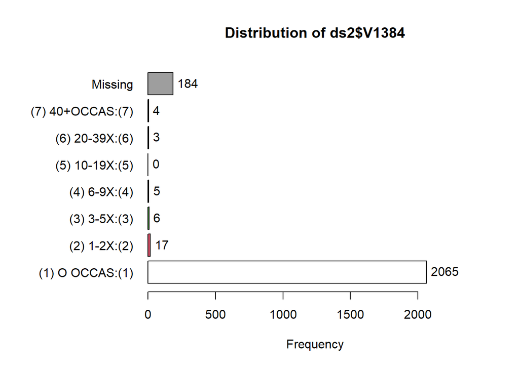

```
## ds2$V1384 :
##                  Frequency   %(NA+) cum.%(NA+)   %(NA-) cum.%(NA-)
## (1) O OCCAS:(1)       2065     90.4       90.4     98.3       98.3
## (2) 1-2X:(2)            17      0.7       91.2      0.8       99.1
## (3) 3-5X:(3)             6      0.3       91.4      0.3       99.4
## (4) 6-9X:(4)             5      0.2       91.6      0.2       99.7
## (5) 10-19X:(5)           0      0.0       91.6      0.0       99.7
## (6) 20-39X:(6)           3      0.1       91.8      0.1       99.8
## (7) 40+OCCAS:(7)         4      0.2       91.9      0.2      100.0
## NA's                   184      8.1      100.0      0.0      100.0
##   Total               2284    100.0      100.0    100.0      100.0
```

```r
tab1(ds2$V1384, cum.percent = TRUE)
```

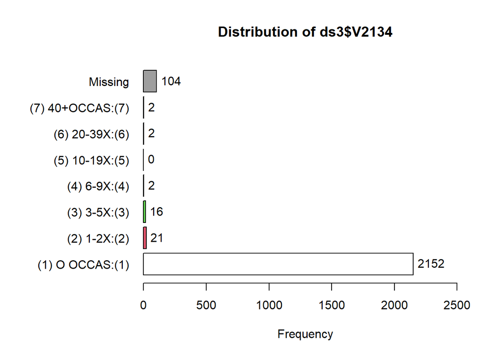

```
## ds3$V2134 :
##                  Frequency   %(NA+) cum.%(NA+)   %(NA-) cum.%(NA-)
## (1) O OCCAS:(1)       2152     93.6       93.6     98.0       98.0
## (2) 1-2X:(2)            21      0.9       94.5      1.0       99.0
## (3) 3-5X:(3)            16      0.7       95.2      0.7       99.7
## (4) 6-9X:(4)             2      0.1       95.3      0.1       99.8
## (5) 10-19X:(5)           0      0.0       95.3      0.0       99.8
## (6) 20-39X:(6)           2      0.1       95.4      0.1       99.9
## (7) 40+OCCAS:(7)         2      0.1       95.5      0.1      100.0
## NA's                   104      4.5      100.0      0.0      100.0
##   Total               2299    100.0      100.0    100.0      100.0
```

```r
tab1(ds3$V2134, cum.percent = TRUE)
```

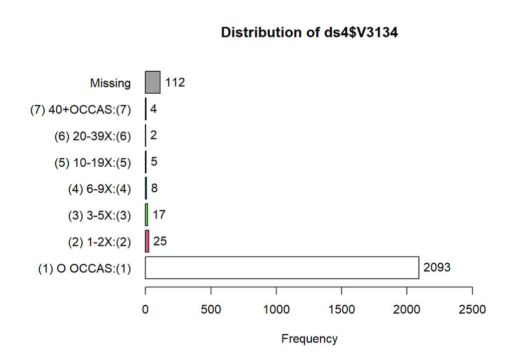

```
## ds4$V3134 :
##                  Frequency   %(NA+) cum.%(NA+)   %(NA-) cum.%(NA-)
## (1) O OCCAS:(1)       2093     92.4       92.4     97.2       97.2
## (2) 1-2X:(2)            25      1.1       93.5      1.2       98.3
## (3) 3-5X:(3)            17      0.8       94.2      0.8       99.1
## (4) 6-9X:(4)             8      0.4       94.6      0.4       99.5
## (5) 10-19X:(5)           5      0.2       94.8      0.2       99.7
## (6) 20-39X:(6)           2      0.1       94.9      0.1       99.8
## (7) 40+OCCAS:(7)         4      0.2       95.1      0.2      100.0
## NA's                   112      4.9      100.0      0.0      100.0
##   Total               2266    100.0      100.0    100.0      100.0
```

```r
tab1(ds4$V3134, cum.percent = TRUE)
```

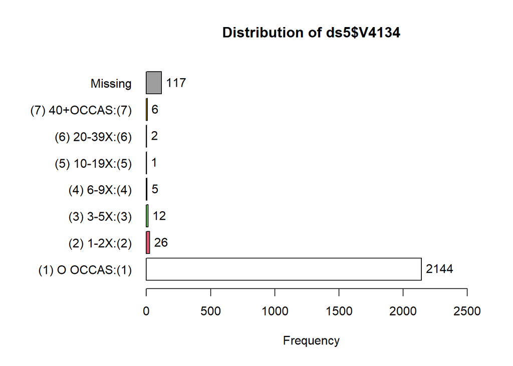

```
## ds5$V4134 :
##                  Frequency   %(NA+) cum.%(NA+)   %(NA-) cum.%(NA-)
## (1) O OCCAS:(1)       2144     92.7       92.7     97.6       97.6
## (2) 1-2X:(2)            26      1.1       93.8      1.2       98.8
## (3) 3-5X:(3)            12      0.5       94.3      0.5       99.4
## (4) 6-9X:(4)             5      0.2       94.6      0.2       99.6
## (5) 10-19X:(5)           1      0.0       94.6      0.0       99.6
## (6) 20-39X:(6)           2      0.1       94.7      0.1       99.7
## (7) 40+OCCAS:(7)         6      0.3       94.9      0.3      100.0
## NA's                   117      5.1      100.0      0.0      100.0
##   Total               2313    100.0      100.0    100.0      100.0
```

```r
tab1(ds5$V4134, cum.percent = TRUE)
```

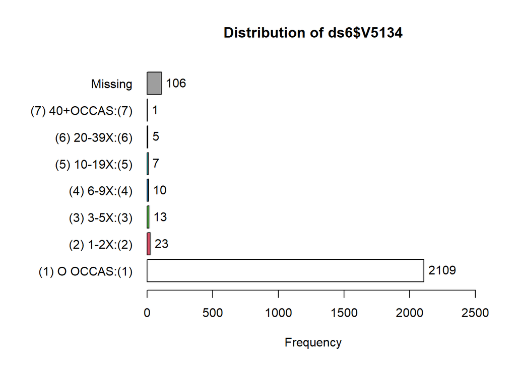

```
## ds6$V5134 :
##                  Frequency   %(NA+) cum.%(NA+)   %(NA-) cum.%(NA-)
## (1) O OCCAS:(1)       2109     92.7       92.7     97.3       97.3
## (2) 1-2X:(2)            23      1.0       93.8      1.1       98.3
## (3) 3-5X:(3)            13      0.6       94.3      0.6       98.9
## (4) 6-9X:(4)            10      0.4       94.8      0.5       99.4
## (5) 10-19X:(5)           7      0.3       95.1      0.3       99.7
## (6) 20-39X:(6)           5      0.2       95.3      0.2      100.0
## (7) 40+OCCAS:(7)         1      0.0       95.3      0.0      100.0
## NA's                   106      4.7      100.0      0.0      100.0
##   Total               2274    100.0      100.0    100.0      100.0
```

```r
tab1(ds6$V5134, cum.percent = TRUE)
```

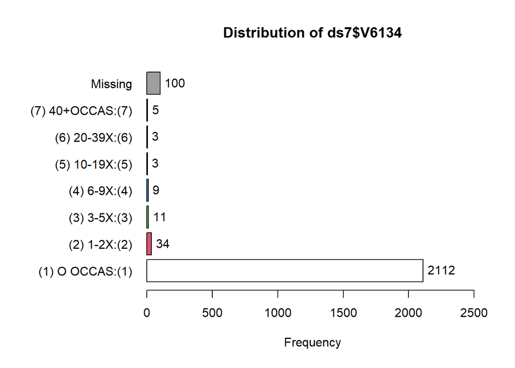

```
## ds7$V6134 :
##                  Frequency   %(NA+) cum.%(NA+)   %(NA-) cum.%(NA-)
## (1) O OCCAS:(1)       2112     92.8       92.8     97.0       97.0
## (2) 1-2X:(2)            34      1.5       94.2      1.6       98.6
## (3) 3-5X:(3)            11      0.5       94.7      0.5       99.1
## (4) 6-9X:(4)             9      0.4       95.1      0.4       99.5
## (5) 10-19X:(5)           3      0.1       95.3      0.1       99.6
## (6) 20-39X:(6)           3      0.1       95.4      0.1       99.8
## (7) 40+OCCAS:(7)         5      0.2       95.6      0.2      100.0
## NA's                   100      4.4      100.0      0.0      100.0
##   Total               2277    100.0      100.0    100.0      100.0
```

```r
tab1(ds7$V6134, cum.percent = TRUE)
```

### 01080:#X TRQL/LAST12MO

{Tranquilizers are sometimes prescribed by doctors to calm people down, quiet their nerves, or relax their muscles. Librium, Valium, and Xanax are all tranquilizers.} On how many occasions (if any) have you taken tranquilizers on your own–that is, without a doctor telling you to take them . . . during the last 12 months?

[Questionnaire form 1 worded somewhat differently and adds Soma, Serax, Ativan, Klonopin to the examples (see form 1 codebook).]

1=“0 Occasions” 2=“1-2 Occasions” 3=“3-5 Occasions” 4=“6-9 Occasions” 5=“10-19 Occasions” 6=“20-39 Occasions” 7=“40 or More”

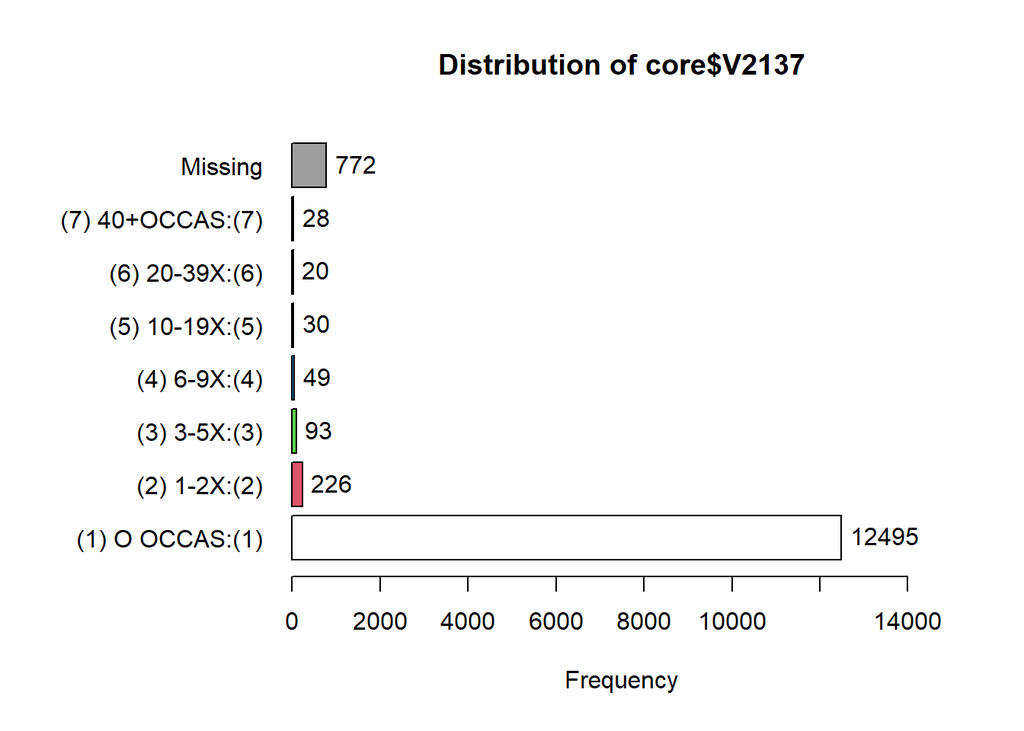

```
## core$V2137 :
##                  Frequency   %(NA+) cum.%(NA+)   %(NA-) cum.%(NA-)
## (1) O OCCAS:(1)      12495     91.1       91.1     96.6       96.6
## (2) 1-2X:(2)           226      1.6       92.8      1.7       98.3
## (3) 3-5X:(3)            93      0.7       93.4      0.7       99.0
## (4) 6-9X:(4)            49      0.4       93.8      0.4       99.4
## (5) 10-19X:(5)          30      0.2       94.0      0.2       99.6
## (6) 20-39X:(6)          20      0.1       94.2      0.2       99.8
## (7) 40+OCCAS:(7)        28      0.2       94.4      0.2      100.0
## NA's                   772      5.6      100.0      0.0      100.0
##   Total              13713    100.0      100.0    100.0      100.0
```

```r
tab1(core$V2137, cum.percent = TRUE)
```

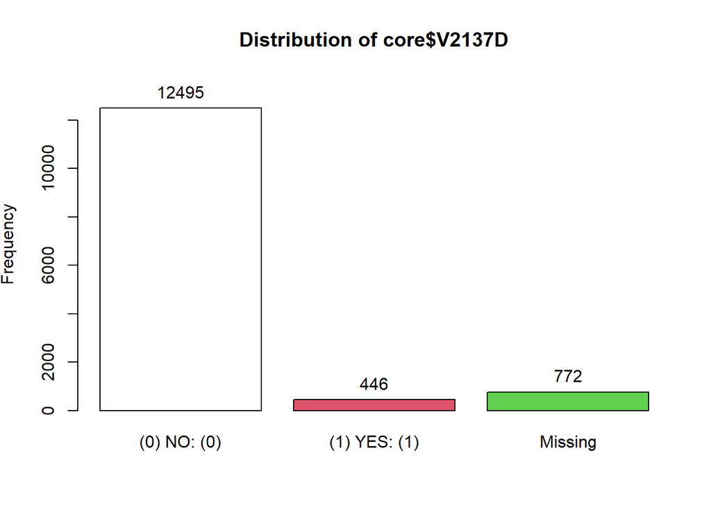

```
## core$V2137D :
##              Frequency   %(NA+) cum.%(NA+)   %(NA-) cum.%(NA-)
## (0) NO: (0)      12495     91.1       91.1     96.6       96.6
## (1) YES: (1)       446      3.3       94.4      3.4      100.0
## NA's               772      5.6      100.0      0.0      100.0
##   Total          13713    100.0      100.0    100.0      100.0
```

```r
tab1(core$V2137D, cum.percent = TRUE)
```

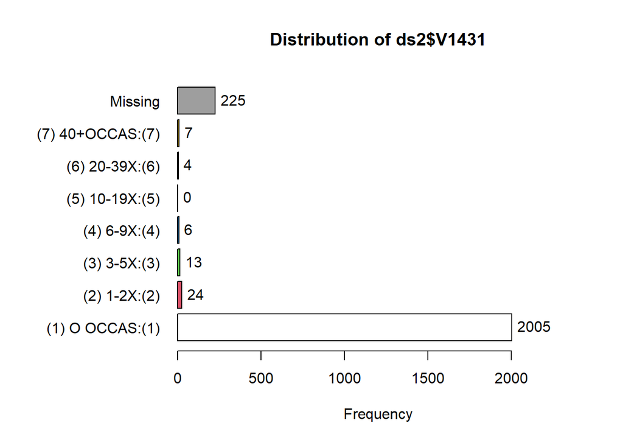

```
## ds2$V1431 :
##                  Frequency   %(NA+) cum.%(NA+)   %(NA-) cum.%(NA-)
## (1) O OCCAS:(1)       2005     87.8       87.8     97.4       97.4
## (2) 1-2X:(2)            24      1.1       88.8      1.2       98.5
## (3) 3-5X:(3)            13      0.6       89.4      0.6       99.2
## (4) 6-9X:(4)             6      0.3       89.7      0.3       99.5
## (5) 10-19X:(5)           0      0.0       89.7      0.0       99.5
## (6) 20-39X:(6)           4      0.2       89.8      0.2       99.7
## (7) 40+OCCAS:(7)         7      0.3       90.1      0.3      100.0
## NA's                   225      9.9      100.0      0.0      100.0
##   Total               2284    100.0      100.0    100.0      100.0
```

```r
tab1(ds2$V1431, cum.percent = TRUE)
```

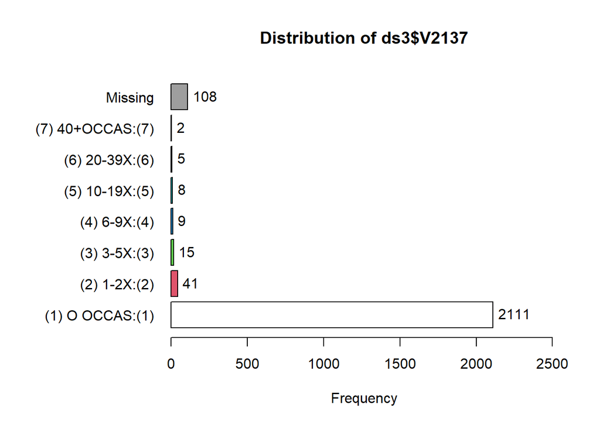

```
## ds3$V2137 :
##                  Frequency   %(NA+) cum.%(NA+)   %(NA-) cum.%(NA-)
## (1) O OCCAS:(1)       2111     91.8       91.8     96.3       96.3
## (2) 1-2X:(2)            41      1.8       93.6      1.9       98.2
## (3) 3-5X:(3)            15      0.7       94.3      0.7       98.9
## (4) 6-9X:(4)             9      0.4       94.6      0.4       99.3
## (5) 10-19X:(5)           8      0.3       95.0      0.4       99.7
## (6) 20-39X:(6)           5      0.2       95.2      0.2       99.9
## (7) 40+OCCAS:(7)         2      0.1       95.3      0.1      100.0
## NA's                   108      4.7      100.0      0.0      100.0
##   Total               2299    100.0      100.0    100.0      100.0
```

```r
tab1(ds3$V2137, cum.percent = TRUE)
```

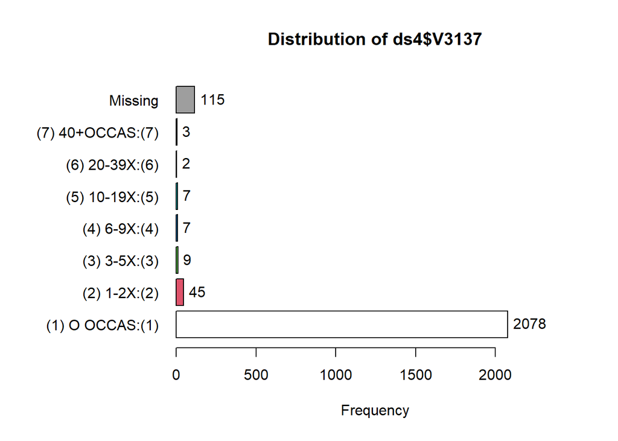

```
## ds4$V3137 :
##                  Frequency   %(NA+) cum.%(NA+)   %(NA-) cum.%(NA-)
## (1) O OCCAS:(1)       2078     91.7       91.7     96.6       96.6
## (2) 1-2X:(2)            45      2.0       93.7      2.1       98.7
## (3) 3-5X:(3)             9      0.4       94.1      0.4       99.1
## (4) 6-9X:(4)             7      0.3       94.4      0.3       99.4
## (5) 10-19X:(5)           7      0.3       94.7      0.3       99.8
## (6) 20-39X:(6)           2      0.1       94.8      0.1       99.9
## (7) 40+OCCAS:(7)         3      0.1       94.9      0.1      100.0
## NA's                   115      5.1      100.0      0.0      100.0
##   Total               2266    100.0      100.0    100.0      100.0
```

```r
tab1(ds4$V3137, cum.percent = TRUE)
```

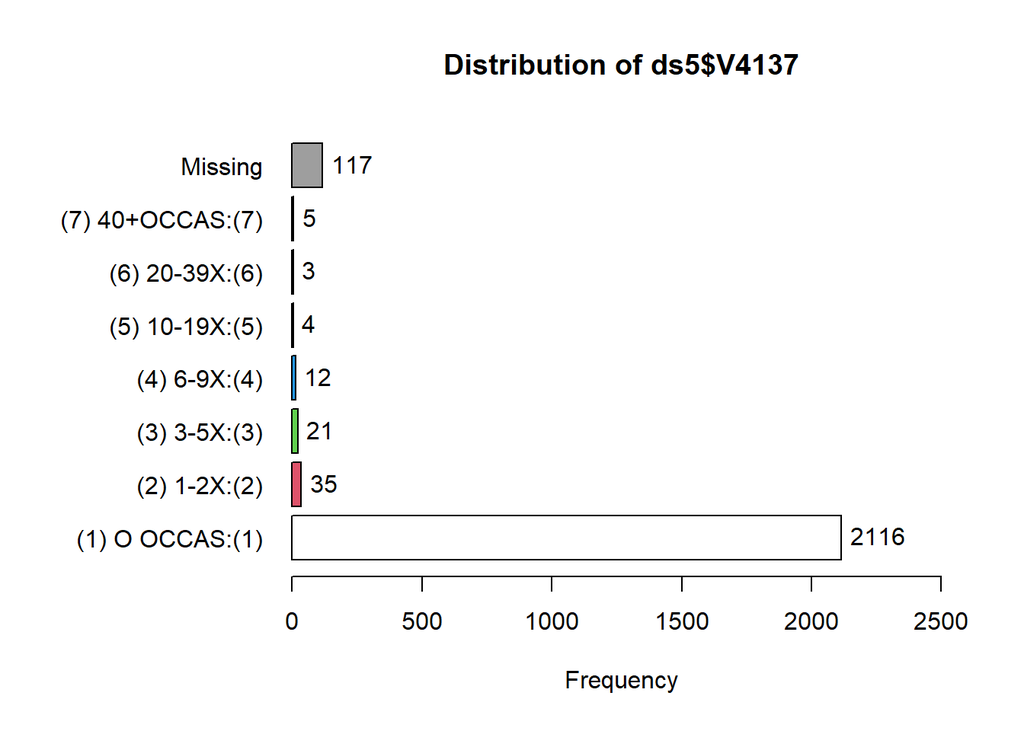

```
## ds5$V4137 :
##                  Frequency   %(NA+) cum.%(NA+)   %(NA-) cum.%(NA-)
## (1) O OCCAS:(1)       2116     91.5       91.5     96.4       96.4
## (2) 1-2X:(2)            35      1.5       93.0      1.6       98.0
## (3) 3-5X:(3)            21      0.9       93.9      1.0       98.9
## (4) 6-9X:(4)            12      0.5       94.4      0.5       99.5
## (5) 10-19X:(5)           4      0.2       94.6      0.2       99.6
## (6) 20-39X:(6)           3      0.1       94.7      0.1       99.8
## (7) 40+OCCAS:(7)         5      0.2       94.9      0.2      100.0
## NA's                   117      5.1      100.0      0.0      100.0
##   Total               2313    100.0      100.0    100.0      100.0
```

```r
tab1(ds5$V4137, cum.percent = TRUE)
```

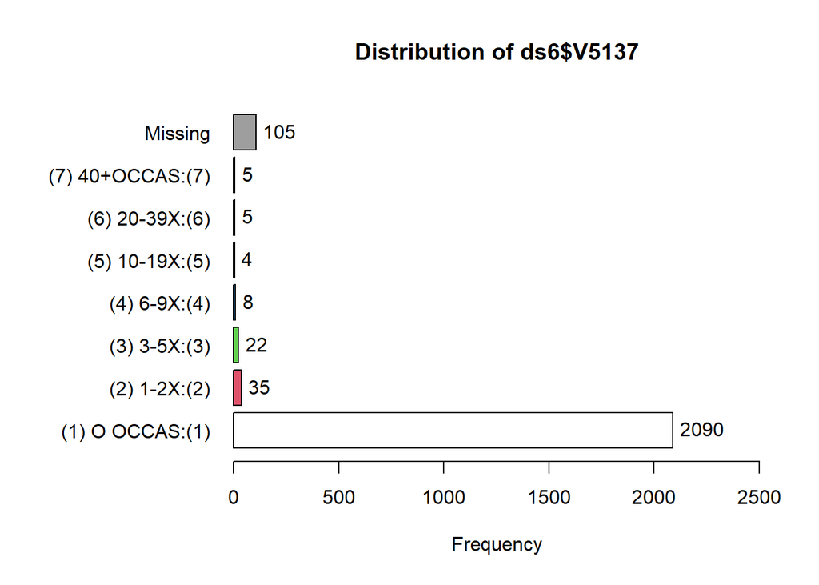

```
## ds6$V5137 :
##                  Frequency   %(NA+) cum.%(NA+)   %(NA-) cum.%(NA-)
## (1) O OCCAS:(1)       2090     91.9       91.9     96.4       96.4
## (2) 1-2X:(2)            35      1.5       93.4      1.6       98.0
## (3) 3-5X:(3)            22      1.0       94.4      1.0       99.0
## (4) 6-9X:(4)             8      0.4       94.8      0.4       99.4
## (5) 10-19X:(5)           4      0.2       94.9      0.2       99.5
## (6) 20-39X:(6)           5      0.2       95.2      0.2       99.8
## (7) 40+OCCAS:(7)         5      0.2       95.4      0.2      100.0
## NA's                   105      4.6      100.0      0.0      100.0
##   Total               2274    100.0      100.0    100.0      100.0
```

```r
tab1(ds6$V5137, cum.percent = TRUE)
```

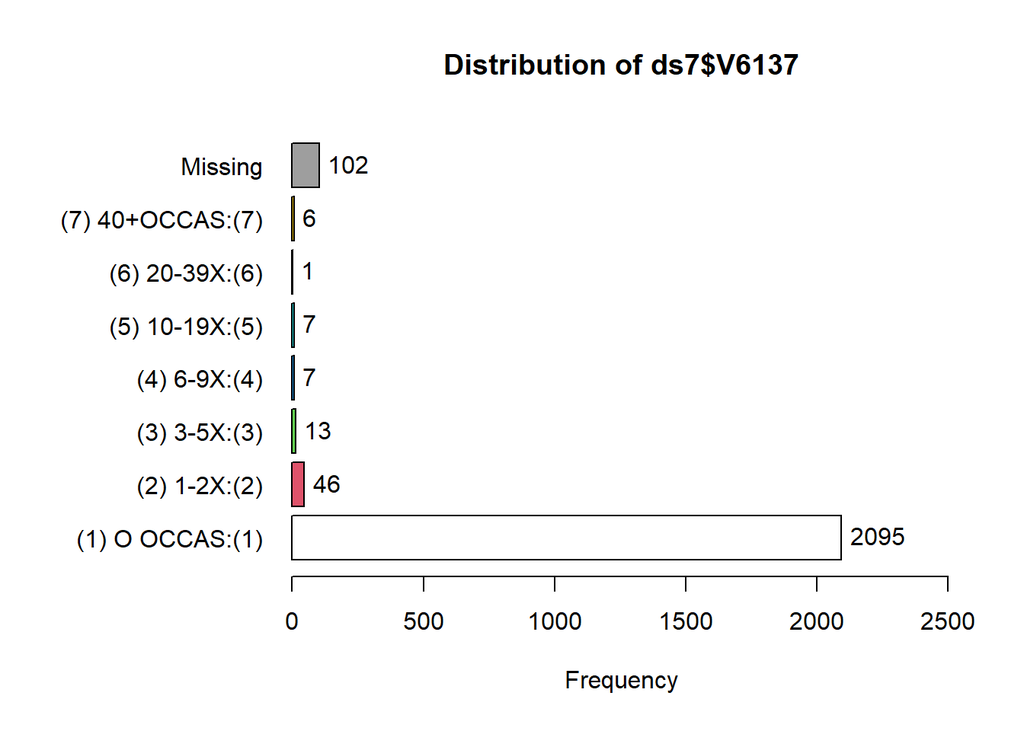

```
## ds7$V6137 :
##                  Frequency   %(NA+) cum.%(NA+)   %(NA-) cum.%(NA-)
## (1) O OCCAS:(1)       2095     92.0       92.0     96.3       96.3
## (2) 1-2X:(2)            46      2.0       94.0      2.1       98.4
## (3) 3-5X:(3)            13      0.6       94.6      0.6       99.0
## (4) 6-9X:(4)             7      0.3       94.9      0.3       99.4
## (5) 10-19X:(5)           7      0.3       95.2      0.3       99.7
## (6) 20-39X:(6)           1      0.0       95.3      0.0       99.7
## (7) 40+OCCAS:(7)         6      0.3       95.5      0.3      100.0
## NA's                   102      4.5      100.0      0.0      100.0
##   Total               2277    100.0      100.0    100.0      100.0
```

```r
tab1(ds7$V6137, cum.percent = TRUE)
```

### 01110:#X ‘H’/LAST 12MO

On how many occasions (if any) have you taken heroin . . . during the last 12 months?

[For questionnaire forms 2, 5, and 6, item is recoded from separate questions about heroin use with a needle (items 29630-29650) and without a needle (items 29660-29680).]

1=“0 Occasions” 2=“1-2 Occasions” 3=“3-5 Occasions” 4=“6-9 Occasions” 5=“10-19 Occasions” 6=“20-39 Occasions” 7=“40 or More”

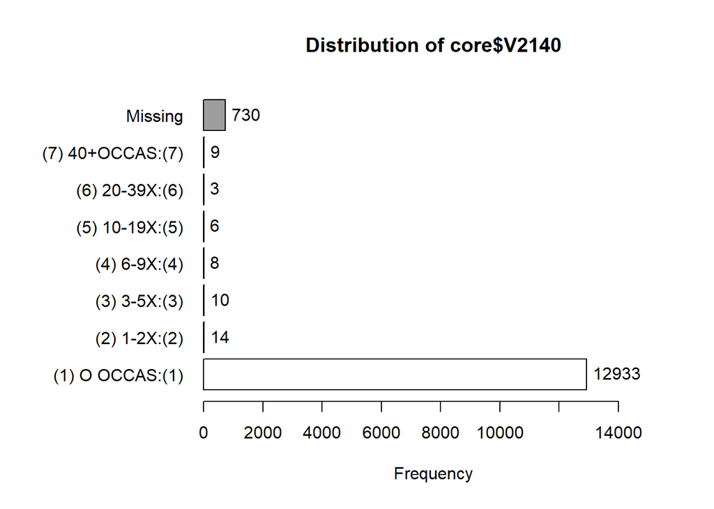

```
## core$V2140 :
##                  Frequency   %(NA+) cum.%(NA+)   %(NA-) cum.%(NA-)
## (1) O OCCAS:(1)      12933     94.3       94.3     99.6       99.6
## (2) 1-2X:(2)            14      0.1       94.4      0.1       99.7
## (3) 3-5X:(3)            10      0.1       94.5      0.1       99.8
## (4) 6-9X:(4)             8      0.1       94.5      0.1       99.9
## (5) 10-19X:(5)           6      0.0       94.6      0.0       99.9
## (6) 20-39X:(6)           3      0.0       94.6      0.0       99.9
## (7) 40+OCCAS:(7)         9      0.1       94.7      0.1      100.0
## NA's                   730      5.3      100.0      0.0      100.0
##   Total              13713    100.0      100.0    100.0      100.0
```

```r
tab1(core$V2140, cum.percent = TRUE)
```

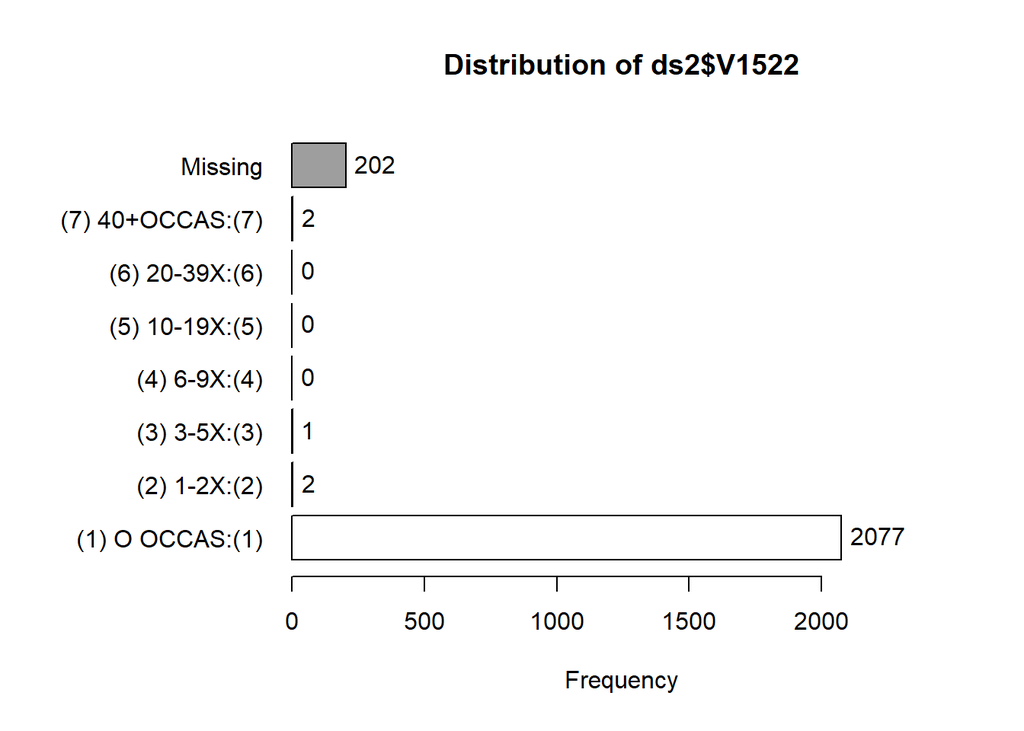

```
## ds2$V1522 :
##                  Frequency   %(NA+) cum.%(NA+)   %(NA-) cum.%(NA-)
## (1) O OCCAS:(1)       2077     90.9       90.9     99.8       99.8
## (2) 1-2X:(2)             2      0.1       91.0      0.1       99.9
## (3) 3-5X:(3)             1      0.0       91.1      0.0       99.9
## (4) 6-9X:(4)             0      0.0       91.1      0.0       99.9
## (5) 10-19X:(5)           0      0.0       91.1      0.0       99.9
## (6) 20-39X:(6)           0      0.0       91.1      0.0       99.9
## (7) 40+OCCAS:(7)         2      0.1       91.2      0.1      100.0
## NA's                   202      8.8      100.0      0.0      100.0
##   Total               2284    100.0      100.0    100.0      100.0
```

```r
tab1(ds2$V1522, cum.percent = TRUE)
```

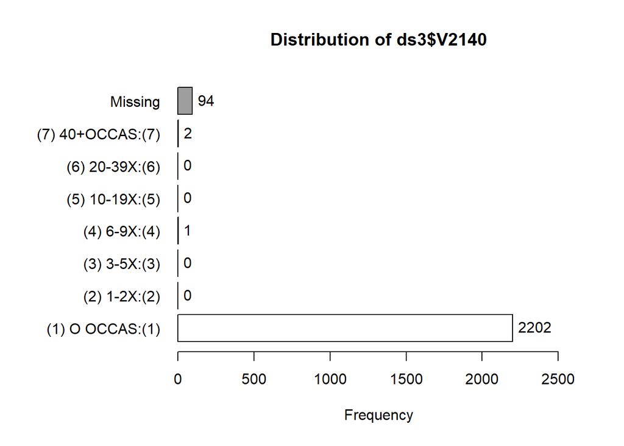

```
## ds3$V2140 :
##                  Frequency   %(NA+) cum.%(NA+)   %(NA-) cum.%(NA-)
## (1) O OCCAS:(1)       2202     95.8       95.8     99.9       99.9
## (2) 1-2X:(2)             0      0.0       95.8      0.0       99.9
## (3) 3-5X:(3)             0      0.0       95.8      0.0       99.9
## (4) 6-9X:(4)             1      0.0       95.8      0.0       99.9
## (5) 10-19X:(5)           0      0.0       95.8      0.0       99.9
## (6) 20-39X:(6)           0      0.0       95.8      0.0       99.9
## (7) 40+OCCAS:(7)         2      0.1       95.9      0.1      100.0
## NA's                    94      4.1      100.0      0.0      100.0
##   Total               2299    100.0      100.0    100.0      100.0
```

```r
tab1(ds3$V2140, cum.percent = TRUE)
```

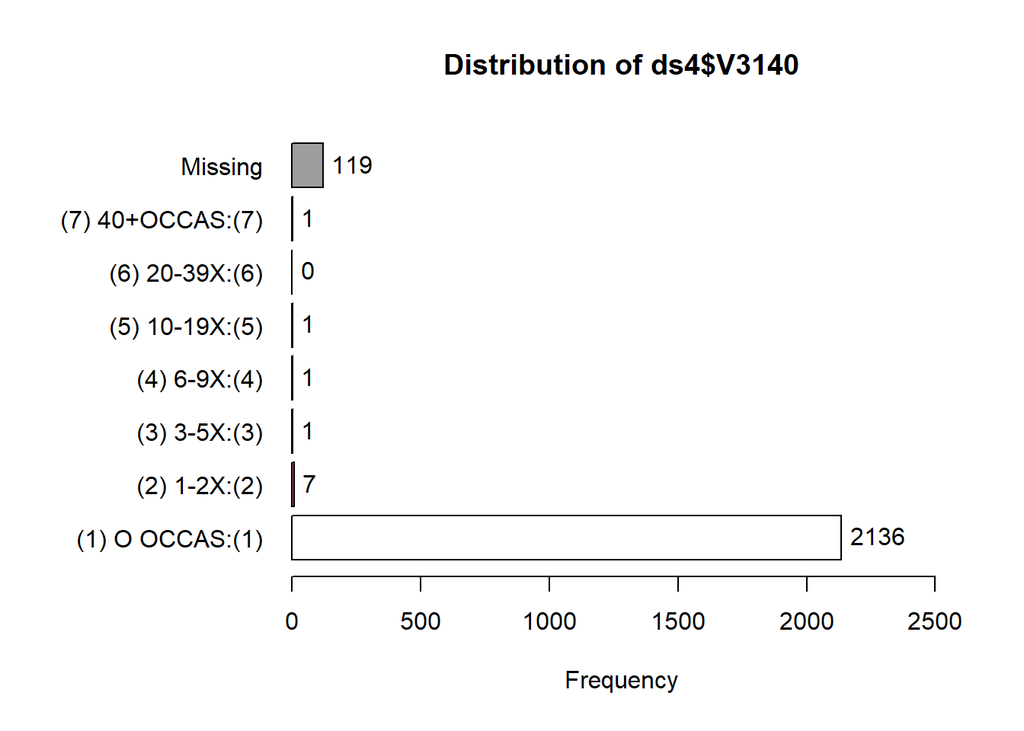

```
## ds4$V3140 :
##                  Frequency   %(NA+) cum.%(NA+)   %(NA-) cum.%(NA-)
## (1) O OCCAS:(1)       2136     94.3       94.3     99.5       99.5
## (2) 1-2X:(2)             7      0.3       94.6      0.3       99.8
## (3) 3-5X:(3)             1      0.0       94.6      0.0       99.9
## (4) 6-9X:(4)             1      0.0       94.7      0.0       99.9
## (5) 10-19X:(5)           1      0.0       94.7      0.0      100.0
## (6) 20-39X:(6)           0      0.0       94.7      0.0      100.0
## (7) 40+OCCAS:(7)         1      0.0       94.7      0.0      100.0
## NA's                   119      5.3      100.0      0.0      100.0
##   Total               2266    100.0      100.0    100.0      100.0
```

```r
tab1(ds4$V3140, cum.percent = TRUE)
```

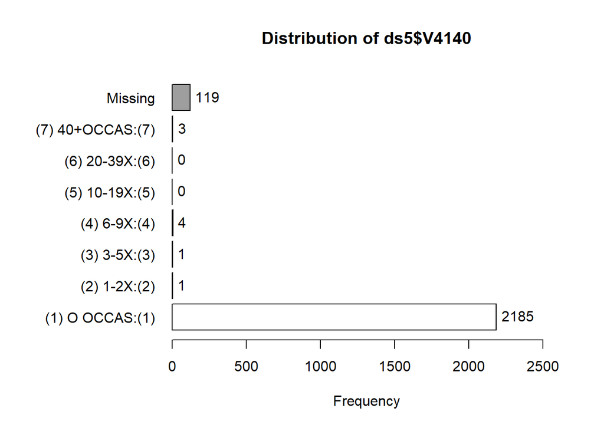

```
## ds5$V4140 :
##                  Frequency   %(NA+) cum.%(NA+)   %(NA-) cum.%(NA-)
## (1) O OCCAS:(1)       2185     94.5       94.5     99.6       99.6
## (2) 1-2X:(2)             1      0.0       94.5      0.0       99.6
## (3) 3-5X:(3)             1      0.0       94.6      0.0       99.7
## (4) 6-9X:(4)             4      0.2       94.7      0.2       99.9
## (5) 10-19X:(5)           0      0.0       94.7      0.0       99.9
## (6) 20-39X:(6)           0      0.0       94.7      0.0       99.9
## (7) 40+OCCAS:(7)         3      0.1       94.9      0.1      100.0
## NA's                   119      5.1      100.0      0.0      100.0
##   Total               2313    100.0      100.0    100.0      100.0
```

```r
tab1(ds5$V4140, cum.percent = TRUE)
```

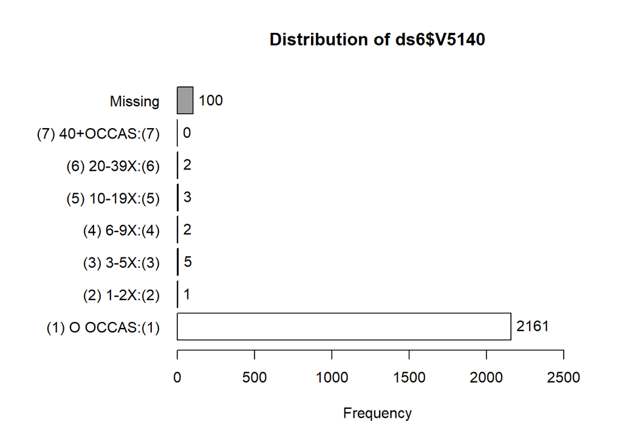

```
## ds6$V5140 :
##                  Frequency   %(NA+) cum.%(NA+)   %(NA-) cum.%(NA-)
## (1) O OCCAS:(1)       2161     95.0       95.0     99.4       99.4
## (2) 1-2X:(2)             1      0.0       95.1      0.0       99.4
## (3) 3-5X:(3)             5      0.2       95.3      0.2       99.7
## (4) 6-9X:(4)             2      0.1       95.4      0.1       99.8
## (5) 10-19X:(5)           3      0.1       95.5      0.1       99.9
## (6) 20-39X:(6)           2      0.1       95.6      0.1      100.0
## (7) 40+OCCAS:(7)         0      0.0       95.6      0.0      100.0
## NA's                   100      4.4      100.0      0.0      100.0
##   Total               2274    100.0      100.0    100.0      100.0
```

```r
tab1(ds6$V5140, cum.percent = TRUE)
```

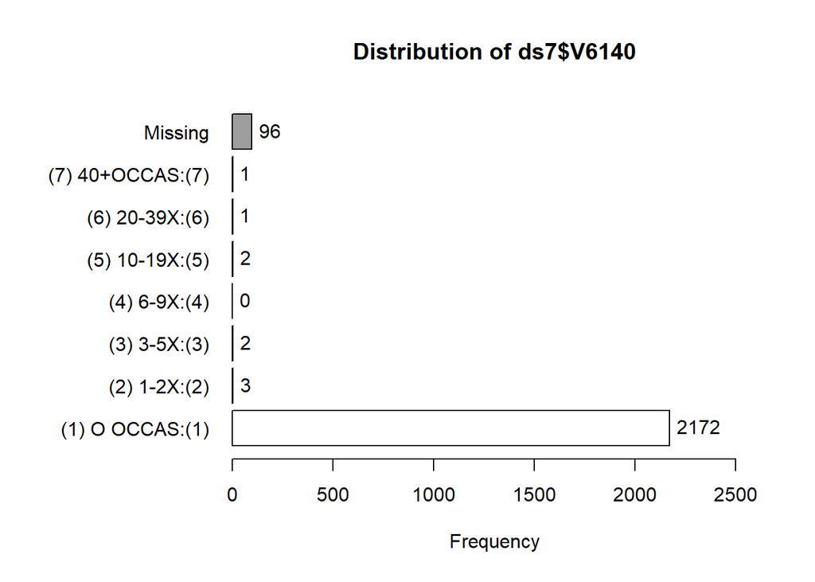

```
## ds7$V6140 :
##                  Frequency   %(NA+) cum.%(NA+)   %(NA-) cum.%(NA-)
## (1) O OCCAS:(1)       2172     95.4       95.4     99.6       99.6
## (2) 1-2X:(2)             3      0.1       95.5      0.1       99.7
## (3) 3-5X:(3)             2      0.1       95.6      0.1       99.8
## (4) 6-9X:(4)             0      0.0       95.6      0.0       99.8
## (5) 10-19X:(5)           2      0.1       95.7      0.1       99.9
## (6) 20-39X:(6)           1      0.0       95.7      0.0      100.0
## (7) 40+OCCAS:(7)         1      0.0       95.8      0.0      100.0
## NA's                    96      4.2      100.0      0.0      100.0
##   Total               2277    100.0      100.0    100.0      100.0
```

```r
tab1(ds7$V6140, cum.percent = TRUE)
```

### 01140:#X NARC/LAST12MO

{There are a number of narcotics other than heroin, such as methadone, opium, morphine, codeine, Demerol, Vicodin, OxyContin, and Percocet. These are sometimes prescribed by doctors.} On how many occasions (if any) have you taken narcotics other than heroin on your own–that is, without a doctor telling you to take them . . . during the last 12 months?

[Questionnaire form 1 worded somewhat differently and adds “Percodan, Ultram” (see form 1 Codebook).]

1=“0 Occasions” 2=“1-2 Occasions” 3=“3-5 Occasions” 4=“6-9 Occasions” 5=“10-19 Occasions” 6=“20-39 Occasions” 7=“40 or More”

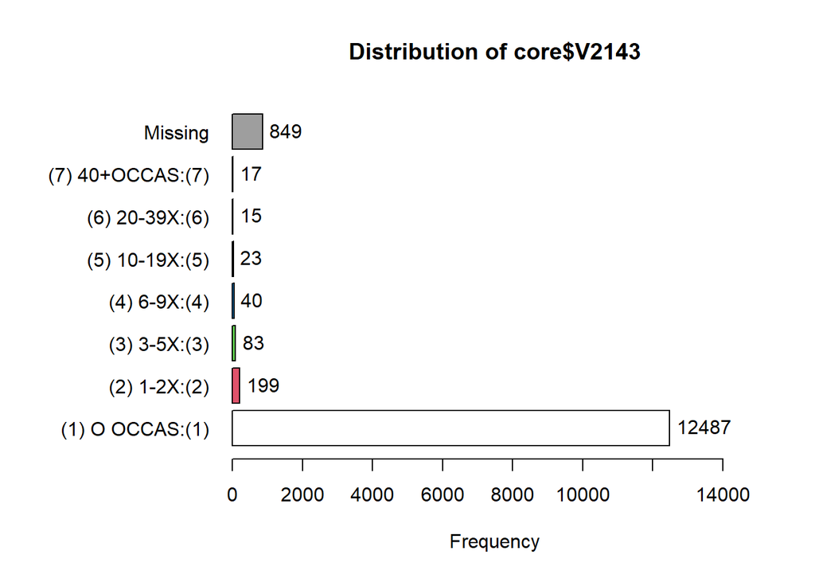

```
## core$V2143 :
##                  Frequency   %(NA+) cum.%(NA+)   %(NA-) cum.%(NA-)
## (1) O OCCAS:(1)      12487     91.1       91.1     97.1       97.1
## (2) 1-2X:(2)           199      1.5       92.5      1.5       98.6
## (3) 3-5X:(3)            83      0.6       93.1      0.6       99.3
## (4) 6-9X:(4)            40      0.3       93.4      0.3       99.6
## (5) 10-19X:(5)          23      0.2       93.6      0.2       99.8
## (6) 20-39X:(6)          15      0.1       93.7      0.1       99.9
## (7) 40+OCCAS:(7)        17      0.1       93.8      0.1      100.0
## NA's                   849      6.2      100.0      0.0      100.0
##   Total              13713    100.0      100.0    100.0      100.0
```

```r
tab1(core$V2143, cum.percent = TRUE)
```

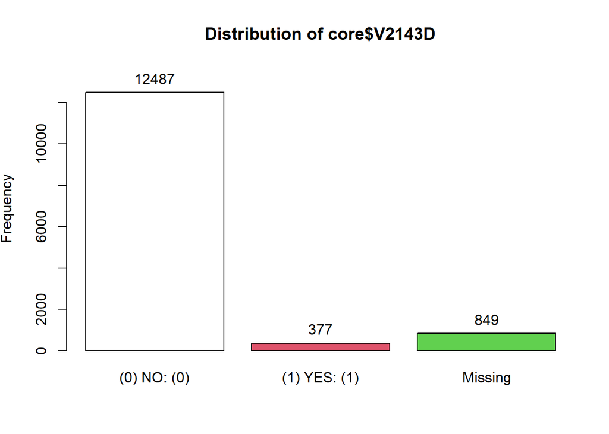

```
## core$V2143D :
##              Frequency   %(NA+) cum.%(NA+)   %(NA-) cum.%(NA-)
## (0) NO: (0)      12487     91.1       91.1     97.1       97.1
## (1) YES: (1)       377      2.7       93.8      2.9      100.0
## NA's               849      6.2      100.0      0.0      100.0
##   Total          13713    100.0      100.0    100.0      100.0
```

```r
tab1(core$V2143D, cum.percent = TRUE)
```